# Impact of News on the Stock Market Indices

```python
#Import packages
import numpy as np
import pandas as pd
from pandas.plotting import scatter_matrix
import matplotlib.pyplot as plt
import seaborn as sns
!pip install pandas-datareader
import pandas_datareader
import datetime
import pandas_datareader.data as web
import requests

from collections import Counter
from sklearn.feature_extraction.text import CountVectorizer
!pip install TextBlob
from textblob import TextBlob

from pandas_datareader import data as pdr
!pip install yfinance
import yfinance

import scipy.stats as stats
import nltk

from nltk.tokenize import sent_tokenize
from nltk.tokenize import word_tokenize
from nltk.probability import FreqDist
from nltk.corpus import stopwords
nltk.download('stopwords')

!pip install wordcloud
from wordcloud import WordCloud
import re

#Use VADER
!pip install vadersentiment
from vaderSentiment.vaderSentiment import SentimentIntensityAnalyzer
analyser = SentimentIntensityAnalyzer()

from urllib.request import urlopen
import requests
from bs4 import BeautifulSoup
import os

!pip install feedparser
import feedparser as fp
import json

!pip install newspaper3k
import newspaper
from newspaper import Article
from time import mktime

from datetime import datetime, timedelta
import time
import pprint

%matplotlib inline

import gensim
from gensim.utils import simple_preprocess
from gensim.parsing.preprocessing import STOPWORDS
from nltk.stem import WordNetLemmatizer, SnowballStemmer
from sklearn.feature_extraction.text import CountVectorizer
from nltk.stem.porter import *
import numpy as np
np.random.seed(2018)
import nltk
nltk.download('wordnet')

from vaderSentiment.vaderSentiment import SentimentIntensityAnalyzer

from wordcloud import WordCloud, STOPWORDS,ImageColorGenerator
from nltk import word_tokenize, sent_tokenize
from nltk.corpus import stopwords
from nltk.stem import LancasterStemmer, WordNetLemmatizer, PorterStemmer
from textblob import TextBlob
from PIL import Image
from os import path

import pandas as pd
import numpy as np
import matplotlib.pyplot as plt
import seaborn as sns
%matplotlib inline
from urllib.request import urlopen
import requests
from bs4 import BeautifulSoup
import os

!pip install feedparser
import feedparser as fp
import json

!pip install newspaper3k
import newspaper
from newspaper import Article
from time import mktime

from datetime import datetime, timedelta
import time
import pprint

import nltk
nltk.download('vader_lexicon')

import json
import requests
from os import makedirs
from os.path import join, exists
from datetime import date, timedelta

import glob

from sklearn.preprocessing import StandardScaler
from sklearn.preprocessing import MinMaxScaler
from sklearn.preprocessing import Normalizer
```

```python
#This will be used when creating graphs to order the days and months
order_days = ['Monday','Tuesday','Wednesday','Thursday','Friday','Saturday','Sunday']
order_month = ['January','February','March','April','May','June','July','August','September','October','November','December']
```

## Loading Data

### Stock Indices Data

#### FTSE 100

```python
ftse = pd.read_csv('FTSE 100 Historical Data.csv')
ftse.head()
```

|  | Date | Price | Open | High | Low | Vol. | Change % |
| --- | --- | --- | --- | --- | --- | --- | --- |
| 0 | Nov 29, 2019 | 7,346.53 | 7,416.43 | 7,421.40 | 7,346.53 | 627.33M | -0.94% |
| 1 | Nov 28, 2019 | 7,416.43 | 7,429.78 | 7,429.78 | 7,385.32 | 605.36M | -0.18% |
| 2 | Nov 27, 2019 | 7,429.78 | 7,403.14 | 7,446.00 | 7,400.38 | 625.05M | 0.36% |
| 3 | Nov 26, 2019 | 7,403.14 | 7,396.29 | 7,421.30 | 7,384.96 | 1.05B | 0.09% |
| 4 | Nov 25, 2019 | 7,396.29 | 7,326.81 | 7,401.78 | 7,326.81 | 570.98M | 0.95% |

```python
ftse.info()
```

```
<class 'pandas.core.frame.DataFrame'>
RangeIndex: 4022 entries, 0 to 4021
Data columns (total 7 columns):
Date        4022 non-null object
Price       4022 non-null object
Open        4022 non-null object
High        4022 non-null object
Low         4022 non-null object
Vol.        4022 non-null object
Change %    4022 non-null object
dtypes: object(7)
memory usage: 220.1+ KB
```

```python
ftse.describe()
```

|  | Date | Price | Open | High | Low | Vol. | Change % |
| --- | --- | --- | --- | --- | --- | --- | --- |
| count | 4022 | 4022 | 4022 | 4022 | 4022 | 4022 | 4022 |
| unique | 4022 | 3942 | 3915 | 3890 | 3895 | 1890 | 565 |
| top | Feb 28, 2011 | 5,791.50 | 5,791.50 | 6,233.10 | 4,898.50 | - | -0.01% |
| freq | 1 | 3 | 4 | 4 | 3 | 1922 | 32 |

```python
#use yfinance and pandas data reader to import the S&P500 index values
SP500 = pdr.get_data_yahoo('^GSPC',
                          start='2004, 1, 1',
                          end='2019, 12, 1')
SP500.reset_index(inplace=True)
SP500.head()
```

|  | Date | High | Low | Open | Close | Volume | Adj Close |
| --- | --- | --- | --- | --- | --- | --- | --- |
| 0 | 2004-01-02 | 1118.849976 | 1105.079956 | 1111.920044 | 1108.479980 | 1153200000 | 1108.479980 |
| 1 | 2004-01-05 | 1122.219971 | 1108.479980 | 1108.479980 | 1122.219971 | 1578200000 | 1122.219971 |
| 2 | 2004-01-06 | 1124.459961 | 1118.439941 | 1122.219971 | 1123.670044 | 1494500000 | 1123.670044 |
| 3 | 2004-01-07 | 1126.329956 | 1116.449951 | 1123.670044 | 1126.329956 | 1704900000 | 1126.329956 |
| 4 | 2004-01-08 | 1131.920044 | 1124.910034 | 1126.329956 | 1131.920044 | 1868400000 | 1131.920044 |

```python
SP500.describe()
```

|  | High | Low | Open | Close | Volume | Adj Close |
| --- | --- | --- | --- | --- | --- | --- |
| count | 4006.000000 | 4006.000000 | 4006.000000 | 4006.000000 | 4.006000e+03 | 4006.000000 |
| mean | 1682.844386 | 1664.709109 | 1674.084690 | 1674.397151 | 3.546413e+09 | 1674.397151 |
| std | 593.347961 | 591.207939 | 592.425408 | 592.441410 | 1.289787e+09 | 592.441410 |
| min | 695.270020 | 666.789978 | 679.280029 | 676.530029 | 5.045800e+08 | 676.530029 |
| 25% | 1219.455048 | 1204.597504 | 1211.492493 | 1212.107544 | 2.816445e+09 | 1212.107544 |
| 50% | 1431.965027 | 1417.440002 | 1426.169983 | 1426.585022 | 3.482505e+09 | 1426.585022 |
| 75% | 2092.982483 | 2073.562439 | 2083.057556 | 2082.357422 | 4.123152e+09 | 2082.357422 |
| max | 3154.260010 | 3143.409912 | 3147.179932 | 3153.629883 | 1.145623e+10 | 3153.629883 |

```python
#Import the exchange rate dataset for AUD/USD
FXUSD = pd.read_csv('USD_GBP Historical Data.csv')
FXUSD.head()
```

|  | Date | Price | Open | High | Low | Change % |
| --- | --- | --- | --- | --- | --- | --- |
| 0 | Nov 29, 2019 | 0.7732 | 0.7743 | 0.7763 | 0.7722 | -0.15% |
| 1 | Nov 28, 2019 | 0.7744 | 0.7739 | 0.7752 | 0.7721 | 0.06% |
| 2 | Nov 27, 2019 | 0.7739 | 0.7772 | 0.7795 | 0.7736 | -0.42% |
| 3 | Nov 26, 2019 | 0.7772 | 0.7752 | 0.7792 | 0.7745 | 0.26% |
| 4 | Nov 25, 2019 | 0.7752 | 0.7782 | 0.7788 | 0.7744 | -0.53% |

```python
FXUSD.describe()
```

|  | Price | Open | High | Low |
| --- | --- | --- | --- | --- |
| count | 4152.000000 | 4152.000000 | 4152.000000 | 4152.000000 |
| mean | 0.635511 | 0.635431 | 0.638428 | 0.632709 |
| std | 0.089655 | 0.089660 | 0.090230 | 0.089125 |
| min | 0.474600 | 0.474600 | 0.476800 | 0.472500 |
| 25% | 0.560975 | 0.560600 | 0.563900 | 0.558375 |
| 50% | 0.629000 | 0.629000 | 0.631700 | 0.626550 |
| 75% | 0.690625 | 0.690625 | 0.694625 | 0.685725 |
| max | 0.831200 | 0.830000 | 0.846100 | 0.827700 |

**Comments**  
FTSE 100 data and USD/GBP exchange rate was obtained from investing.com[9][11] and S&P500 information uses the yfinance and pandas datareader package[12][13].

### News Data

```python
guardian_api = '8ca75031-03ce-4640-80b3-9accc793d8e6'
```

```python
ARTICLES_DIR = join('tempdata', 'newsarticles') #Create a temporary directory to save the news articles
makedirs(ARTICLES_DIR, exist_ok=True)
# Sample URL - obtained from guardian to search for news articles
#
# http://content.guardianapis.com/search?q=news
# &api-key=your-api-key-goes-here

MY_API_KEY = open("creds_guardian.txt").read().strip()
API_ENDPOINT = 'http://content.guardianapis.com/search?q=news'
my_params = {
    'from-date': "",
    'to-date': "",
    'order-by': "newest",
    'show-fields': 'all',
    'page-size': 200,
    'api-key': guardian_api
}
```

```python
my_params
```

```
{'from-date': '',
 'to-date': '',
 'order-by': 'newest',
 'show-fields': 'all',
 'page-size': 200,
 'api-key': '8ca75031-03ce-4640-80b3-9accc793d8e6'}
```

```python
# #CODE HAS BEEN COMMENTED OUT AS IT WILL OVERWRITE INFORMATION STORED IN THE TEMPORARY DIRECTORY.
# #The code below uses the API request to gather news article information from The Guardian
# # day iteration from here:
# # http://stackoverflow.com/questions/7274267/print-all-day-dates-between-two-dates
# start_date = date(2004, 1, 1)
# end_date = date(2010,12, 31) #ONLY ALLOWED 5,000 API REQUESTS SO SPLIT INTO BATCHES
# dayrange = range((end_date - start_date).days + 1)
# for daycount in dayrange:
#     dt = start_date + timedelta(days=daycount)
#     datestr = dt.strftime('%Y-%m-%d')
#     fname = join(ARTICLES_DIR, datestr + '.json')
#     if not exists(fname):
#         # then let's download it
#         print("Downloading", datestr)
#         all_results = []
#         my_params['from-date'] = datestr
#         my_params['to-date'] = datestr
#         current_page = 1
#         total_pages = 1
#         while current_page <= total_pages:
#             print("...page", current_page)
#             my_params['page'] = current_page
#             resp = requests.get(API_ENDPOINT, my_params)
#             data = resp.json()
#             all_results.extend(data['response']['results'])
#             # if there is more than one page
#             current_page += 1
#             total_pages = data['response']['pages']

#         with open(fname, 'w') as f:
#             print("Writing to", fname)

#             # re-serialize it for pretty indentation
#             f.write(json.dumps(all_results, indent=2)) #create separate json files for each day and save it in the tempdata/articles/ folder
```

**Comments**

The Guardian has released an API to request news articles from the website. The Guardian allows 5,000 API calls per day. The range is from 01/01/2004 to 31/12/2019, which has more than 5,000 API calls, hence code has been run over 3 days to avoid reaching the maximum calls.

The code to request the API has been modified from Dan Nguyen [21], to only search for news articles and adjusted the date range for this analysis.

## Read in the JSON files

```python
#Find names of all files in the folder tempdata/newsarticles/ with the extension .json
pattern = 'tempdata/newsarticles/*.json'

json_files = glob.glob(pattern)

print(json_files)
```

```
['tempdata/newsarticles\\2004-01-01.json', 'tempdata/newsarticles\\2004-01-02.json', 'tempdata/newsarticles\\2004-01-03.json', 'tempdata/newsarticles\\2004-01-04.json', 'tempdata/newsarticles\\2004-01-05.json', 'tempdata/newsarticles\\2004-01-06.json', 'tempdata/newsarticles\\2004-01-07.json', 'temp…
```

```python
json2 = pd.read_json(json_files[1])
```

```python
json2
```

|  | id | type | sectionId | sectionName | webPublicationDate | webTitle | webUrl | apiUrl | fields | isHosted | pillarId | pillarName |
| --- | --- | --- | --- | --- | --- | --- | --- | --- | --- | --- | --- | --- |
| 0 | football/2004/jan/02/newsstory.sport4 | article | football | Football | 2004-01-02T21:20:29Z | Lazio accept Mancini may move on | https://www.theguardian.com/football/2004/jan/... | https://content.guardianapis.com/football/2004... | {'headline': 'Lazio accept Mancini may move on... | False | pillar/sport | Sport |
| 1 | uk/2004/jan/02/3 | article | uk-news | UK news | 2004-01-02T15:32:19Z | Pedants' revolt leaves bobby red-faced | https://www.theguardian.com/uk/2004/jan/02/3 | https://content.guardianapis.com/uk/2004/jan/02/3 | {'headline': 'Pedants' revolt leaves bobby red... | False | pillar/news | News |
| 2 | news/2004/jan/02/informer | article | world | World news | 2004-01-02T14:01:07Z | BA cancels second flight to US | https://www.theguardian.com/news/2004/jan/02/i... | https://content.guardianapis.com/news/2004/jan... | {'headline': 'BA cancels second flight to US',... | False | pillar/news | News |
| 3 | uk/2004/jan/02/northerner.martinwainwright | article | uk-news | UK news | 2004-01-02T12:32:27Z | Bother in Bolton | https://www.theguardian.com/uk/2004/jan/02/nor... | https://content.guardianapis.com/uk/2004/jan/0... | {'headline': 'Bother in Bolton', 'trailText': ... | False | pillar/news | News |
| 4 | science/2004/jan/02/spaceexploration.starsgala... | article | science | Science | 2004-01-02T10:07:25Z | 'Star suburb' is des res for aliens | https://www.theguardian.com/science/2004/jan/0... | https://content.guardianapis.com/science/2004/... | {'headline': ''Star suburb' is des res for ali... | False | pillar/news | News |
| 5 | uk/2004/jan/02/2 | article | uk-news | UK news | 2004-01-02T01:59:40Z | UK news in brief | https://www.theguardian.com/uk/2004/jan/02/2 | https://content.guardianapis.com/uk/2004/jan/02/2 | {'headline': 'In brief', 'trailText': 'Opt-out... | False | pillar/news | News |
| 6 | theguardian/2004/jan/02/features11.g22 | article | books | Books | 2004-01-02T01:06:10Z | The prize quiz | https://www.theguardian.com/theguardian/2004/j... | https://content.guardianapis.com/theguardian/2... | {'headline': 'The prize quiz', 'trailText': 'A... | False | pillar/arts | Arts |
| 7 | film/2004/jan/02/rupertmurdoch.australia | article | film | Film | 2004-01-02T01:05:39Z | David Fickling on controversial film Black and... | https://www.theguardian.com/film/2004/jan/02/r... | https://content.guardianapis.com/film/2004/jan... | {'headline': 'Rupert the Brave', 'standfirst':... | False | pillar/arts | Arts |
| 8 | business/2004/jan/02/dowjones.usnews | article | business | Business | 2004-01-02T01:05:37Z | US business review of the year | https://www.theguardian.com/business/2004/jan/... | https://content.guardianapis.com/business/2004... | {'headline': 'Scent of sleaze persists amid US... | False | pillar/news | News |
| 9 | world/2004/jan/02/usa.iran | article | world | World news | 2004-01-02T01:05:37Z | Iranian leaders welcome easing of US sanctions | https://www.theguardian.com/world/2004/jan/02/... | https://content.guardianapis.com/world/2004/ja... | {'headline': 'Iranian leaders welcome easing o... | False | pillar/news | News |
| 10 | uk/2004/jan/02/1 | article | uk-news | UK news | 2004-01-02T01:05:33Z | Family 'devastated' by death of twins in fire | https://www.theguardian.com/uk/2004/jan/02/1 | https://content.guardianapis.com/uk/2004/jan/02/1 | {'headline': 'Family 'devastated' by death of ... | False | pillar/news | News |
| 11 | business/2004/jan/02/corporatefraud.theeuro | article | business | Business | 2004-01-02T01:05:33Z | Corporate Europe chilled by Enron-style scandal | https://www.theguardian.com/business/2004/jan/... | https://content.guardianapis.com/business/2004... | {'headline': 'Corporate Europe chilled by Enro... | False | pillar/news | News |
| 12 | uk/2004/jan/02/ukcrime.religion | article | uk-news | UK news | 2004-01-02T01:05:32Z | Met inquires into alleged slur on Sikh temples | https://www.theguardian.com/uk/2004/jan/02/ukc... | https://content.guardianapis.com/uk/2004/jan/0... | {'headline': 'Met inquires into alleged slur o... | False | pillar/news | News |
| 13 | world/2004/jan/02/gender.uk | article | world | World news | 2004-01-02T01:05:31Z | Dye another day | https://www.theguardian.com/world/2004/jan/02/... | https://content.guardianapis.com/world/2004/ja... | {'headline': 'Dye another day', 'standfirst': ... | False | pillar/news | News |
| 14 | world/2004/jan/02/china.japan | article | world | World news | 2004-01-02T01:04:43Z | Fury at visit to shrine by Japan's PM | https://www.theguardian.com/world/2004/jan/02/... | https://content.guardianapis.com/world/2004/ja... | {'headline': 'Fury at visit to shrine by Japan... | False | pillar/news | News |
| 15 | business/2004/jan/02/1 | article | business | Business | 2004-01-02T01:04:39Z | Stock up on 2004's top tips | https://www.theguardian.com/business/2004/jan/... | https://content.guardianapis.com/business/2004... | {'headline': 'Stock up on 2004's top tips', 's... | False | pillar/news | News |

```python
#Inspired by tutorial on data cleaning in DataCamp [22]
#In order to read in the files, the code needs to iterate over each JSON file in the tempdata/articles/ file and
#create a separate pandas dataframe for each day. Once this is done, concantenate each day into one big data frame
#Create an empty list called frames

frames = []

#iterate over json_files

for json in json_files:
    #read json into a dataframe called newsdata
    newsdata = pd.read_json(json)

    #append newsdata to frames
    frames.append(newsdata)

#Concatenate frames into a single dataframe called news articles
newsarticles = pd.concat(frames)

#Print the shape of newsarticles
print(newsarticles.shape)
```

```
(307633, 12)
```

```python
newsarticles.head(50)
```

|  | id | type | sectionId | sectionName | webPublicationDate | webTitle | webUrl | apiUrl | fields | isHosted | pillarId | pillarName |
| --- | --- | --- | --- | --- | --- | --- | --- | --- | --- | --- | --- | --- |
| 0 | sport/2004/jan/01/rugbyunion.paulrees | article | sport | Sport | 2004-01-01T22:55:20Z | Wilkinson boost for Six Nations | https://www.theguardian.com/sport/2004/jan/01/... | https://content.guardianapis.com/sport/2004/ja... | {'headline': 'Wilkinson boost for Six Nations'... | False | pillar/sport | Sport |
| 1 | world/2004/jan/01/southafrica.uk | article | world | World news | 2004-01-01T15:09:06Z | 8 Britons killed in South Africa road crash | https://www.theguardian.com/world/2004/jan/01/... | https://content.guardianapis.com/world/2004/ja... | {'headline': '8 Britons killed in South Africa... | False | pillar/news | News |
| 2 | world/2004/jan/01/israel.antiwar | article | world | World news | 2004-01-01T13:56:10Z | Israeli soldier held on shooting of Briton | https://www.theguardian.com/world/2004/jan/01/... | https://content.guardianapis.com/world/2004/ja... | {'headline': 'Israeli soldier held on shooting... | False | pillar/news | News |
| 3 | politics/2004/jan/01/uk.research1 | article | politics | Politics | 2004-01-01T10:29:03Z | Aitken's Middle East foray sparked row | https://www.theguardian.com/politics/2004/jan/... | https://content.guardianapis.com/politics/2004... | {'headline': 'Aitken's Middle East foray spark... | False | pillar/news | News |
| 4 | politics/2004/jan/01/uk.artsandhumanities | article | politics | Politics | 2004-01-01T10:27:36Z | Heath feared US plan to invade Gulf | https://www.theguardian.com/politics/2004/jan/... | https://content.guardianapis.com/politics/2004... | {'headline': 'Heath feared US plan to invade G... | False | pillar/news | News |
| 5 | world/2004/jan/01/worlddispatch.johnaglionby | article | world | World news | 2004-01-01T08:25:32Z | Doors close on free press | https://www.theguardian.com/world/2004/jan/01/... | https://content.guardianapis.com/world/2004/ja... | {'headline': 'Doors close on free press', 'sta... | False | pillar/news | News |
| 6 | theguardian/2004/jan/01/features11.g2 | article | books | Books | 2004-01-01T01:28:59Z | The prize quiz set by Ali Amith | https://www.theguardian.com/theguardian/2004/j... | https://content.guardianapis.com/theguardian/2... | {'headline': 'The prize quiz', 'trailText': 'T... | False | pillar/arts | Arts |
| 7 | theguardian/2004/jan/01/guardianleaders | article | theguardian | From the Guardian | 2004-01-01T01:28:59Z | Leader: Share tipsters | https://www.theguardian.com/theguardian/2004/j... | https://content.guardianapis.com/theguardian/2... | {'headline': 'Playing FTSE', 'trailText': 'Why... | False | pillar/news | News |
| 8 | media/2004/jan/01/tvandradio.television1 | article | culture | Culture | 2004-01-01T01:28:25Z | TV pick of the day | https://www.theguardian.com/media/2004/jan/01/... | https://content.guardianapis.com/media/2004/ja... | {'headline': 'Pick of the day', 'trailText': '... | False | pillar/arts | Arts |
| 9 | politics/2004/jan/01/uk.past1 | article | politics | Politics | 2004-01-01T01:28:25Z | News from 1973 in brief | https://www.theguardian.com/politics/2004/jan/... | https://content.guardianapis.com/politics/2004... | {'headline': 'News from 1973 in brief', 'trail... | False | pillar/news | News |
| 10 | uk/2004/jan/01/1 | article | uk-news | UK news | 2004-01-01T01:28:23Z | UK news in brief | https://www.theguardian.com/uk/2004/jan/01/1 | https://content.guardianapis.com/uk/2004/jan/01/1 | {'headline': 'In brief', 'trailText': 'Baby lo... | False | pillar/news | News |
| 11 | business/2004/jan/01/corporatefraud.italy | article | business | Business | 2004-01-01T01:28:20Z | More arrests as Parmalat fraud scandal deepens | https://www.theguardian.com/business/2004/jan/... | https://content.guardianapis.com/business/2004... | {'headline': 'More arrests as Parmalat fraud s... | False | pillar/news | News |
| 12 | politics/2004/jan/01/uk.past3 | article | politics | Politics | 2004-01-01T01:28:20Z | UK feared US would invade Gulf during 1973 oil... | https://www.theguardian.com/politics/2004/jan/... | https://content.guardianapis.com/politics/2004... | {'headline': 'UK feared Americans would invade... | False | pillar/news | News |
| 13 | world/2004/jan/01/china2 | article | world | World news | 2004-01-01T01:27:51Z | Yangtze water plan extended | https://www.theguardian.com/world/2004/jan/01/... | https://content.guardianapis.com/world/2004/ja... | {'headline': 'Yangtze water plan extended', 't... | False | pillar/news | News |
| 14 | world/2004/jan/01/china | article | world | World news | 2004-01-01T01:27:50Z | Beijing bursts balloon plot | https://www.theguardian.com/world/2004/jan/01/... | https://content.guardianapis.com/world/2004/ja... | {'headline': 'Beijing bursts balloon plot', 't... | False | pillar/news | News |
| 15 | film/2004/jan/01/cybercinema | article | film | Film | 2004-01-01T00:00:00Z | Cyber cinema: New year - higher resolution | https://www.theguardian.com/film/2004/jan/01/c... | https://content.guardianapis.com/film/2004/jan... | {'headline': 'Cyber cinema: New year - higher ... | False | pillar/arts | Arts |
| 0 | football/2004/jan/02/newsstory.sport4 | article | football | Football | 2004-01-02T21:20:29Z | Lazio accept Mancini may move on | https://www.theguardian.com/football/2004/jan/... | https://content.guardianapis.com/football/2004... | {'headline': 'Lazio accept Mancini may move on... | False | pillar/sport | Sport |
| 1 | uk/2004/jan/02/3 | article | uk-news | UK news | 2004-01-02T15:32:19Z | Pedants' revolt leaves bobby red-faced | https://www.theguardian.com/uk/2004/jan/02/3 | https://content.guardianapis.com/uk/2004/jan/02/3 | {'headline': 'Pedants' revolt leaves bobby red... | False | pillar/news | News |
| 2 | news/2004/jan/02/informer | article | world | World news | 2004-01-02T14:01:07Z | BA cancels second flight to US | https://www.theguardian.com/news/2004/jan/02/i... | https://content.guardianapis.com/news/2004/jan... | {'headline': 'BA cancels second flight to US',... | False | pillar/news | News |
| 3 | uk/2004/jan/02/northerner.martinwainwright | article | uk-news | UK news | 2004-01-02T12:32:27Z | Bother in Bolton | https://www.theguardian.com/uk/2004/jan/02/nor... | https://content.guardianapis.com/uk/2004/jan/0... | {'headline': 'Bother in Bolton', 'trailText': ... | False | pillar/news | News |
| 4 | science/2004/jan/02/spaceexploration.starsgala... | article | science | Science | 2004-01-02T10:07:25Z | 'Star suburb' is des res for aliens | https://www.theguardian.com/science/2004/jan/0... | https://content.guardianapis.com/science/2004/... | {'headline': ''Star suburb' is des res for ali... | False | pillar/news | News |
| 5 | uk/2004/jan/02/2 | article | uk-news | UK news | 2004-01-02T01:59:40Z | UK news in brief | https://www.theguardian.com/uk/2004/jan/02/2 | https://content.guardianapis.com/uk/2004/jan/02/2 | {'headline': 'In brief', 'trailText': 'Opt-out... | False | pillar/news | News |
| 6 | theguardian/2004/jan/02/features11.g22 | article | books | Books | 2004-01-02T01:06:10Z | The prize quiz | https://www.theguardian.com/theguardian/2004/j... | https://content.guardianapis.com/theguardian/2... | {'headline': 'The prize quiz', 'trailText': 'A... | False | pillar/arts | Arts |
| 7 | film/2004/jan/02/rupertmurdoch.australia | article | film | Film | 2004-01-02T01:05:39Z | David Fickling on controversial film Black and... | https://www.theguardian.com/film/2004/jan/02/r... | https://content.guardianapis.com/film/2004/jan... | {'headline': 'Rupert the Brave', 'standfirst':... | False | pillar/arts | Arts |
| 8 | business/2004/jan/02/dowjones.usnews | article | business | Business | 2004-01-02T01:05:37Z | US business review of the year | https://www.theguardian.com/business/2004/jan/... | https://content.guardianapis.com/business/2004... | {'headline': 'Scent of sleaze persists amid US... | False | pillar/news | News |
| 9 | world/2004/jan/02/usa.iran | article | world | World news | 2004-01-02T01:05:37Z | Iranian leaders welcome easing of US sanctions | https://www.theguardian.com/world/2004/jan/02/... | https://content.guardianapis.com/world/2004/ja... | {'headline': 'Iranian leaders welcome easing o... | False | pillar/news | News |
| 10 | uk/2004/jan/02/1 | article | uk-news | UK news | 2004-01-02T01:05:33Z | Family 'devastated' by death of twins in fire | https://www.theguardian.com/uk/2004/jan/02/1 | https://content.guardianapis.com/uk/2004/jan/02/1 | {'headline': 'Family 'devastated' by death of ... | False | pillar/news | News |
| 11 | business/2004/jan/02/corporatefraud.theeuro | article | business | Business | 2004-01-02T01:05:33Z | Corporate Europe chilled by Enron-style scandal | https://www.theguardian.com/business/2004/jan/... | https://content.guardianapis.com/business/2004... | {'headline': 'Corporate Europe chilled by Enro... | False | pillar/news | News |
| 12 | uk/2004/jan/02/ukcrime.religion | article | uk-news | UK news | 2004-01-02T01:05:32Z | Met inquires into alleged slur on Sikh temples | https://www.theguardian.com/uk/2004/jan/02/ukc... | https://content.guardianapis.com/uk/2004/jan/0... | {'headline': 'Met inquires into alleged slur o... | False | pillar/news | News |
| 13 | world/2004/jan/02/gender.uk | article | world | World news | 2004-01-02T01:05:31Z | Dye another day | https://www.theguardian.com/world/2004/jan/02/... | https://content.guardianapis.com/world/2004/ja... | {'headline': 'Dye another day', 'standfirst': ... | False | pillar/news | News |
| 14 | world/2004/jan/02/china.japan | article | world | World news | 2004-01-02T01:04:43Z | Fury at visit to shrine by Japan's PM | https://www.theguardian.com/world/2004/jan/02/... | https://content.guardianapis.com/world/2004/ja... | {'headline': 'Fury at visit to shrine by Japan... | False | pillar/news | News |
| 15 | business/2004/jan/02/1 | article | business | Business | 2004-01-02T01:04:39Z | Stock up on 2004's top tips | https://www.theguardian.com/business/2004/jan/... | https://content.guardianapis.com/business/2004... | {'headline': 'Stock up on 2004's top tips', 's... | False | pillar/news | News |
| 0 | travel/2004/jan/03/guardiansaturdaytravelsection2 | article | travel | Travel | 2004-01-03T19:40:04Z | This year's news | https://www.theguardian.com/travel/2004/jan/03... | https://content.guardianapis.com/travel/2004/j... | {'headline': 'This year's news', 'standfirst':... | False | pillar/lifestyle | Lifestyle |
| 1 | books/2004/jan/03/fiction.features | article | books | Books | 2004-01-03T02:37:20Z | Is it really all about me? | https://www.theguardian.com/books/2004/jan/03/... | https://content.guardianapis.com/books/2004/ja... | {'headline': 'Is it really all about me?', 'st... | False | pillar/arts | Arts |
| 2 | media/2004/jan/03/radio.bbc | article | media | Media | 2004-01-03T01:40:10Z | Leader: Vox pop | https://www.theguardian.com/media/2004/jan/03/... | https://content.guardianapis.com/media/2004/ja... | {'headline': 'Listeners' lynch law', 'trailTex... | False | pillar/news | News |
| 3 | uk/2004/jan/03/society.politics | article | uk-news | UK news | 2004-01-03T01:40:08Z | Pub chain to ban smoking in 50 outlets | https://www.theguardian.com/uk/2004/jan/03/soc... | https://content.guardianapis.com/uk/2004/jan/0... | {'headline': 'Pub chain to ban smoking in 50 o... | False | pillar/news | News |
| 4 | technology/2004/jan/03/usnews.internationalnews | article | technology | Technology | 2004-01-03T01:03:30Z | Plug pulled on live website seen by millions | https://www.theguardian.com/technology/2004/ja... | https://content.guardianapis.com/technology/20... | {'headline': 'Plug pulled on live website seen... | False | pillar/news | News |
| 5 | world/2004/jan/03/1 | article | world | World news | 2004-01-03T01:03:30Z | International news in brief | https://www.theguardian.com/world/2004/jan/03/1 | https://content.guardianapis.com/world/2004/ja... | {'headline': 'In brief', 'trailText': 'Germany... | False | pillar/news | News |
| 6 | world/2004/jan/03/sars.china | article | world | World news | 2004-01-03T01:03:30Z | China braced for new Sars outbreak | https://www.theguardian.com/world/2004/jan/03/... | https://content.guardianapis.com/world/2004/ja... | {'headline': 'China braced for new Sars outbre... | False | pillar/news | News |
| 7 | news/2004/jan/03/terrorism | article | world | World news | 2004-01-03T01:02:54Z | Passengers frustrated as BA flight cancelled | https://www.theguardian.com/news/2004/jan/03/t... | https://content.guardianapis.com/news/2004/jan... | {'headline': 'The view from the queue: 'It's r... | False | pillar/news | News |
| 8 | culture/2004/jan/03/comedy.television | article | culture | Culture | 2004-01-03T01:02:52Z | Interview: comedy writer Julia Davis | https://www.theguardian.com/culture/2004/jan/0... | https://content.guardianapis.com/culture/2004/... | {'headline': 'Dye of laughter', 'standfirst': ... | False | pillar/arts | Arts |
| 9 | world/2004/jan/03/russia.usa | article | world | World news | 2004-01-03T01:02:51Z | Jonathan Steele: The new cold war | https://www.theguardian.com/world/2004/jan/03/... | https://content.guardianapis.com/world/2004/ja... | {'headline': 'The new cold war', 'standfirst':... | False | pillar/news | News |
| 10 | uk/2004/jan/03/christmas.comment | article | uk-news | UK news | 2004-01-03T01:02:49Z | Simon Hoggart: Despite the castration, it's be... | https://www.theguardian.com/uk/2004/jan/03/chr... | https://content.guardianapis.com/uk/2004/jan/0... | {'headline': 'Despite the castration, it's bee... | False | pillar/news | News |
| 11 | uk/2004/jan/03/1 | article | uk-news | UK news | 2004-01-03T01:02:47Z | UK news in brief | https://www.theguardian.com/uk/2004/jan/03/1 | https://content.guardianapis.com/uk/2004/jan/03/1 | {'headline': 'In brief', 'trailText': 'Pension... | False | pillar/news | News |
| 12 | society/2004/jan/03/christmasappeal.internatio... | article | society | Society | 2004-01-03T01:02:27Z | 'Beautiful' disease which soon turns ugly | https://www.theguardian.com/society/2004/jan/0... | https://content.guardianapis.com/society/2004/... | {'headline': ''Beautiful' disease which soon t... | False | pillar/news | News |
| 13 | books/2004/jan/03/news.comment | article | books | Books | 2004-01-03T01:02:25Z | Smallweed | https://www.theguardian.com/books/2004/jan/03/... | https://content.guardianapis.com/books/2004/ja... | {'headline': 'Smallweed', 'trailText': '<p>200... | False | pillar/arts | Arts |
| 14 | business/2004/jan/03/money | article | business | Business | 2004-01-03T01:02:24Z | WH Smith warns of profits slump | https://www.theguardian.com/business/2004/jan/... | https://content.guardianapis.com/business/2004... | {'headline': 'WH Smith warns of profits slump'... | False | pillar/news | News |
| 15 | business/2004/jan/03/manufacturing.ukeconomy | article | business | Business | 2004-01-03T01:02:24Z | Manufacturers ring in new year on buoyant note | https://www.theguardian.com/business/2004/jan/... | https://content.guardianapis.com/business/2004... | {'headline': 'Manufacturers ring in new year o... | False | pillar/news | News |
| 16 | business/2004/jan/03/3 | article | business | Business | 2004-01-03T01:02:24Z | Edmond Warner: Normal service is at hand | https://www.theguardian.com/business/2004/jan/... | https://content.guardianapis.com/business/2004... | {'headline': 'Normal service is at hand', 'sta... | False | pillar/news | News |
| 17 | business/2004/jan/03/5 | article | business | Business | 2004-01-03T01:02:24Z | Business news in brief | https://www.theguardian.com/business/2004/jan/... | https://content.guardianapis.com/business/2004... | {'headline': 'In brief', 'trailText': '<p>Post... | False | pillar/news | News |

```python
# Check if there are missing values in the dataset
newsarticles['id'].isna().sum()
```

```
0
```

```python
newsarticles.shape[0]

print('There are',newsarticles.shape[0],'rows and',newsarticles.shape[1],'columns')
```

```
There are 307633 rows and 12 columns
```

## Processing Data

### Cleaning Data

#### News Dataset

```python
newsarticles['pillarName'].unique()
```

```
array(['Sport', 'News', 'Arts', 'Lifestyle', nan, 'Opinion'], dtype=object)
```

```python
#Only keep values where the pillarName = 'News'
newsarticles2 = newsarticles[newsarticles['pillarName'] == 'News']
newsarticles2.shape
```

```
(193068, 12)
```

```python
newsarticles2.head()
```

|  | id | type | sectionId | sectionName | webPublicationDate | webTitle | webUrl | apiUrl | fields | isHosted | pillarId | pillarName |
| --- | --- | --- | --- | --- | --- | --- | --- | --- | --- | --- | --- | --- |
| 1 | world/2004/jan/01/southafrica.uk | article | world | World news | 2004-01-01T15:09:06Z | 8 Britons killed in South Africa road crash | https://www.theguardian.com/world/2004/jan/01/... | https://content.guardianapis.com/world/2004/ja... | {'headline': '8 Britons killed in South Africa... | False | pillar/news | News |
| 2 | world/2004/jan/01/israel.antiwar | article | world | World news | 2004-01-01T13:56:10Z | Israeli soldier held on shooting of Briton | https://www.theguardian.com/world/2004/jan/01/... | https://content.guardianapis.com/world/2004/ja... | {'headline': 'Israeli soldier held on shooting... | False | pillar/news | News |
| 3 | politics/2004/jan/01/uk.research1 | article | politics | Politics | 2004-01-01T10:29:03Z | Aitken's Middle East foray sparked row | https://www.theguardian.com/politics/2004/jan/... | https://content.guardianapis.com/politics/2004... | {'headline': 'Aitken's Middle East foray spark... | False | pillar/news | News |
| 4 | politics/2004/jan/01/uk.artsandhumanities | article | politics | Politics | 2004-01-01T10:27:36Z | Heath feared US plan to invade Gulf | https://www.theguardian.com/politics/2004/jan/... | https://content.guardianapis.com/politics/2004... | {'headline': 'Heath feared US plan to invade G... | False | pillar/news | News |
| 5 | world/2004/jan/01/worlddispatch.johnaglionby | article | world | World news | 2004-01-01T08:25:32Z | Doors close on free press | https://www.theguardian.com/world/2004/jan/01/... | https://content.guardianapis.com/world/2004/ja... | {'headline': 'Doors close on free press', 'sta... | False | pillar/news | News |

```python
newsarticles2.info()
```

```
<class 'pandas.core.frame.DataFrame'>
Int64Index: 193068 entries, 1 to 22
Data columns (total 12 columns):
id                    193068 non-null object
type                  193068 non-null object
sectionId             193068 non-null object
sectionName           193068 non-null object
webPublicationDate    193068 non-null object
webTitle              193068 non-null object
webUrl                193068 non-null object
apiUrl                193068 non-null object
fields                193068 non-null object
isHosted              193068 non-null bool
pillarId              193068 non-null object
pillarName            193068 non-null object
dtypes: bool(1), object(11)
memory usage: 17.9+ MB
```

```python
#Create a new dataframe which has the web publication date only
publicationdate = newsarticles2[['webPublicationDate']]
publicationdate.reset_index(drop = True, inplace = True)
publicationdate.head()
```

|  | webPublicationDate |
| --- | --- |
| 0 | 2004-01-01T15:09:06Z |
| 1 | 2004-01-01T13:56:10Z |
| 2 | 2004-01-01T10:29:03Z |
| 3 | 2004-01-01T10:27:36Z |
| 4 | 2004-01-01T08:25:32Z |

```python
#Column fields has the relevant information required for this analysis
newsarticlesdf = newsarticles2['fields'].apply(pd.Series)
print(newsarticlesdf.shape)
```

```
(193068, 36)
```

```python
#Reset index
newsarticlesdf.reset_index(drop = True, inplace = True)
newsarticlesdf.head()
```

|  | headline | trailText | byline | main | body | wordcount | commentable | isPremoderated | lastModified | newspaperEditionDate | ... | thumbnail | starRating | sensitive | shouldHideReaderRevenue | firstPublicationDate | liveBloggingNow | displayHint | allowUgc | contributorBio | membershipAccess |
| --- | --- | --- | --- | --- | --- | --- | --- | --- | --- | --- | --- | --- | --- | --- | --- | --- | --- | --- | --- | --- | --- |
| 0 | 8 Britons killed in South Africa road crash | Eight British tourists were killed in South Af... | Agencies |  | Eight British tourists were killed in South Af... | 735 | false | false | 2004-01-01T15:09:06Z | 2004-01-01T00:00:00Z | ... | NaN | NaN | NaN | NaN | NaN | NaN | NaN | NaN | NaN | NaN |
| 1 | Israeli soldier held on shooting of Briton | NaN | Chris McGreal in Jerusalem |  | <b>The following correction was printed in the... | 769 | false | false | 2017-05-08T07:32:28Z | 2004-01-01T00:00:00Z | ... | NaN | NaN | NaN | NaN | NaN | NaN | NaN | NaN | NaN | NaN |
| 2 | Aitken's Middle East foray sparked row | Jonathan Aitken so infuriated the Foreign Offi... | Owen Bowcott |  | Jonathan Aitken so infuriated the Foreign Offi... | 447 | false | false | 2017-05-08T07:32:29Z | 2004-01-01T00:00:00Z | ... | NaN | NaN | NaN | NaN | NaN | NaN | NaN | NaN | NaN | NaN |
| 3 | Heath feared US plan to invade Gulf | Ted Heath's government feared - at the height ... | Owen Bowcott |  | Ted Heath's government feared - at the height ... | 364 | false | false | 2017-07-15T03:37:56Z | 2004-01-01T00:00:00Z | ... | NaN | NaN | NaN | NaN | NaN | NaN | NaN | NaN | NaN | NaN |
| 4 | Doors close on free press | There is no end in sight to the dangerous rest... | John Aglionby |  | A former Vietnamese journalist, Nguyen Vu Binh... | 739 | false | false | 2004-01-02T08:25:32Z | 2004-01-01T00:00:00Z | ... | NaN | NaN | NaN | NaN | NaN | NaN | NaN | NaN | NaN | NaN |

5 rows × 36 columns

```python
newsarticlesdf.info()
```

```
<class 'pandas.core.frame.DataFrame'>
RangeIndex: 193068 entries, 0 to 193067
Data columns (total 36 columns):
headline                         193068 non-null object
trailText                        192787 non-null object
byline                           176458 non-null object
main                             193068 non-null object
body                             193068 non-null object
wordcount                        193068 non-null object
commentable                      164606 non-null object
isPremoderated                   193068 non-null object
lastModified                     193068 non-null object
newspaperEditionDate             149843 non-null object
productionOffice                 192268 non-null object
publication                      193068 non-null object
shortUrl                         193068 non-null object
shouldHideAdverts                193064 non-null object
showInRelatedContent             193064 non-null object
legallySensitive                 172910 non-null object
lang                             193068 non-null object
bodyText                         193068 non-null object
charCount                        193068 non-null object
bylineHtml                       176458 non-null object
newspaperPageNumber              70534 non-null object
standfirst                       140894 non-null object
commentCloseDate                 76787 non-null object
isInappropriateForSponsorship    56120 non-null object
showAffiliateLinks               13111 non-null object
isLive                           2445 non-null object
thumbnail                        45513 non-null object
starRating                       55 non-null object
sensitive                        7468 non-null object
shouldHideReaderRevenue          20033 non-null object
firstPublicationDate             61903 non-null object
liveBloggingNow                  6929 non-null object
displayHint                      2094 non-null object
allowUgc                         1190 non-null object
contributorBio                   995 non-null object
membershipAccess                 40 non-null object
dtypes: object(36)
memory usage: 53.0+ MB
```

```python
#Merge the publicationdate df with the newsarticles df to obtain the publication date of the article.
newsarticlesdate = newsarticlesdf.merge(publicationdate,left_index = True, right_index = True)
newsarticlesdate.head()
```

|  | headline | trailText | byline | main | body | wordcount | commentable | isPremoderated | lastModified | newspaperEditionDate | ... | starRating | sensitive | shouldHideReaderRevenue | firstPublicationDate | liveBloggingNow | displayHint | allowUgc | contributorBio | membershipAccess | webPublicationDate |
| --- | --- | --- | --- | --- | --- | --- | --- | --- | --- | --- | --- | --- | --- | --- | --- | --- | --- | --- | --- | --- | --- |
| 0 | 8 Britons killed in South Africa road crash | Eight British tourists were killed in South Af... | Agencies |  | Eight British tourists were killed in South Af... | 735 | false | false | 2004-01-01T15:09:06Z | 2004-01-01T00:00:00Z | ... | NaN | NaN | NaN | NaN | NaN | NaN | NaN | NaN | NaN | 2004-01-01T15:09:06Z |
| 1 | Israeli soldier held on shooting of Briton | NaN | Chris McGreal in Jerusalem |  | <b>The following correction was printed in the... | 769 | false | false | 2017-05-08T07:32:28Z | 2004-01-01T00:00:00Z | ... | NaN | NaN | NaN | NaN | NaN | NaN | NaN | NaN | NaN | 2004-01-01T13:56:10Z |
| 2 | Aitken's Middle East foray sparked row | Jonathan Aitken so infuriated the Foreign Offi... | Owen Bowcott |  | Jonathan Aitken so infuriated the Foreign Offi... | 447 | false | false | 2017-05-08T07:32:29Z | 2004-01-01T00:00:00Z | ... | NaN | NaN | NaN | NaN | NaN | NaN | NaN | NaN | NaN | 2004-01-01T10:29:03Z |
| 3 | Heath feared US plan to invade Gulf | Ted Heath's government feared - at the height ... | Owen Bowcott |  | Ted Heath's government feared - at the height ... | 364 | false | false | 2017-07-15T03:37:56Z | 2004-01-01T00:00:00Z | ... | NaN | NaN | NaN | NaN | NaN | NaN | NaN | NaN | NaN | 2004-01-01T10:27:36Z |
| 4 | Doors close on free press | There is no end in sight to the dangerous rest... | John Aglionby |  | A former Vietnamese journalist, Nguyen Vu Binh... | 739 | false | false | 2004-01-02T08:25:32Z | 2004-01-01T00:00:00Z | ... | NaN | NaN | NaN | NaN | NaN | NaN | NaN | NaN | NaN | 2004-01-01T08:25:32Z |

5 rows × 37 columns

```python
#Keep necessary columns for this investigation
newsarticlesdf2 = newsarticlesdate[['headline','body','charCount','wordcount','lastModified','publication','webPublicationDate']]
newsarticlesdf2.head()
```

|  | headline | body | charCount | wordcount | lastModified | publication | webPublicationDate |
| --- | --- | --- | --- | --- | --- | --- | --- |
| 0 | 8 Britons killed in South Africa road crash | Eight British tourists were killed in South Af... | 4282 | 735 | 2004-01-01T15:09:06Z | theguardian.com | 2004-01-01T15:09:06Z |
| 1 | Israeli soldier held on shooting of Briton | <b>The following correction was printed in the... | 4581 | 769 | 2017-05-08T07:32:28Z | theguardian.com | 2004-01-01T13:56:10Z |
| 2 | Aitken's Middle East foray sparked row | Jonathan Aitken so infuriated the Foreign Offi... | 2778 | 447 | 2017-05-08T07:32:29Z | theguardian.com | 2004-01-01T10:29:03Z |
| 3 | Heath feared US plan to invade Gulf | Ted Heath's government feared - at the height ... | 2270 | 364 | 2017-07-15T03:37:56Z | theguardian.com | 2004-01-01T10:27:36Z |
| 4 | Doors close on free press | A former Vietnamese journalist, Nguyen Vu Binh... | 4678 | 739 | 2004-01-02T08:25:32Z | theguardian.com | 2004-01-01T08:25:32Z |

**Comments**  
Web publication date has been taken from the original dataset and merged to get the original date of publication. The webPublicationdate is present for all rows.

```python
#Convert lastmodified date to date time
newsarticlesdf2['PublicationDate'] = pd.to_datetime(newsarticlesdf2['webPublicationDate'],errors = 'coerce')
```

```python
#Check for NA
newsarticlesdf2.isna().sum()
```

```
headline              0
body                  0
charCount             0
wordcount             0
lastModified          0
publication           0
webPublicationDate    0
PublicationDate       0
dtype: int64
```

#### Stock Indices Dataset

```python
#Find the type of each of the columns
ftse.dtypes
```

```
Date        object
Price       object
Open        object
High        object
Low         object
Vol.        object
Change %    object
dtype: object
```

```python
SP500.dtypes
```

```
Date         datetime64[ns]
High                float64
Low                 float64
Open                float64
Close               float64
Volume                int64
Adj Close           float64
dtype: object
```

```python
#Drop columns that are not needed in the analysis
ftse.drop(labels = ['High','Open','Low','Vol.','Change %'], axis = 'columns', inplace = True)
SP500.drop(labels = ['High','Low','Open','Volume','Adj Close'], axis = 'columns', inplace = True)
```

```python
ftse.head()
```

|  | Date | Price |
| --- | --- | --- |
| 0 | Nov 29, 2019 | 7,346.53 |
| 1 | Nov 28, 2019 | 7,416.43 |
| 2 | Nov 27, 2019 | 7,429.78 |
| 3 | Nov 26, 2019 | 7,403.14 |
| 4 | Nov 25, 2019 | 7,396.29 |

```python
SP500.head()
```

|  | Date | Close |
| --- | --- | --- |
| 0 | 2004-01-02 | 1108.479980 |
| 1 | 2004-01-05 | 1122.219971 |
| 2 | 2004-01-06 | 1123.670044 |
| 3 | 2004-01-07 | 1126.329956 |
| 4 | 2004-01-08 | 1131.920044 |

```python
#Rename Price to Close to match the SP 500 dataset
ftse.columns = ['Date','Close']
```

```python
#The close price on the FTSE dataset included commas so use replace the commas with '' and then conver to float64 as you can't convert it otherwise
ftse['Date'] = pd.to_datetime(ftse['Date'])
ftse['Close'] = ftse['Close'].replace(',','',regex=True).astype(np.float64)
ftse.head()
```

|  | Date | Close |
| --- | --- | --- |
| 0 | 2019-11-29 | 7346.53 |
| 1 | 2019-11-28 | 7416.43 |
| 2 | 2019-11-27 | 7429.78 |
| 3 | 2019-11-26 | 7403.14 |
| 4 | 2019-11-25 | 7396.29 |

```python
#Find the missing dates from the dataset
ftsedates = pd.date_range(start = ftse.Date.min(), end = ftse.Date.max())
ftseNew = ftse.set_index('Date').reindex(ftsedates).rename_axis('Date').reset_index()
```

```python
ftseNew.head()
```

|  | Date | Close |
| --- | --- | --- |
| 0 | 2004-01-02 | 4510.2 |
| 1 | 2004-01-03 | NaN |
| 2 | 2004-01-04 | NaN |
| 3 | 2004-01-05 | 4513.3 |
| 4 | 2004-01-06 | 4505.2 |

```python
#Fill the missing dates which have NA values with the previous date.
ftseNew['Close'].fillna(method='ffill', inplace=True)
```

```python
ftseNew.head()
```

|  | Date | Close |
| --- | --- | --- |
| 0 | 2004-01-02 | 4510.2 |
| 1 | 2004-01-03 | 4510.2 |
| 2 | 2004-01-04 | 4510.2 |
| 3 | 2004-01-05 | 4513.3 |
| 4 | 2004-01-06 | 4505.2 |

```python
SP500.info()
```

```
<class 'pandas.core.frame.DataFrame'>
RangeIndex: 4006 entries, 0 to 4005
Data columns (total 2 columns):
Date     4006 non-null datetime64[ns]
Close    4006 non-null float64
dtypes: datetime64[ns](1), float64(1)
memory usage: 62.7 KB
```

```python
#Find the missing dates from the dataset
SP500dates = pd.date_range(start = SP500.Date.min(), end = SP500.Date.max())
SP500New = SP500.set_index('Date').reindex(SP500dates).rename_axis('Date').reset_index()
```

```python
SP500New.head()
```

|  | Date | Close |
| --- | --- | --- |
| 0 | 2004-01-02 | 1108.479980 |
| 1 | 2004-01-03 | NaN |
| 2 | 2004-01-04 | NaN |
| 3 | 2004-01-05 | 1122.219971 |
| 4 | 2004-01-06 | 1123.670044 |

```python
#Fill the missing dates which have NA values with the previous date.
SP500New['Close'].fillna(method='ffill', inplace=True)
```

```python
SP500New.head()
```

|  | Date | Close |
| --- | --- | --- |
| 0 | 2004-01-02 | 1108.479980 |
| 1 | 2004-01-03 | 1108.479980 |
| 2 | 2004-01-04 | 1108.479980 |
| 3 | 2004-01-05 | 1122.219971 |
| 4 | 2004-01-06 | 1123.670044 |

```python
#To do time series analysis, set the index to be the date column
ftseTime = ftseNew.set_index('Date')
ftseTime.head()
```

| Date | Close |
| --- | --- |
| 2004-01-02 | 4510.2 |
| 2004-01-03 | 4510.2 |
| 2004-01-04 | 4510.2 |
| 2004-01-05 | 4513.3 |
| 2004-01-06 | 4505.2 |

```python
SP500Time = SP500New.set_index('Date')
SP500Time.head()
```

| Date | Close |
| --- | --- |
| 2004-01-02 | 1108.479980 |
| 2004-01-03 | 1108.479980 |
| 2004-01-04 | 1108.479980 |
| 2004-01-05 | 1122.219971 |
| 2004-01-06 | 1123.670044 |

#### Exchange Rate dataset

```python
#Drop columns Open, High and Low columns as we are only interested with the price on the day
FXUSD.drop(labels = ['Open','High','Low'], axis = 'columns', inplace = True)
FXUSD.head()
```

|  | Date | Price | Change % |
| --- | --- | --- | --- |
| 0 | Nov 29, 2019 | 0.7732 | -0.15% |
| 1 | Nov 28, 2019 | 0.7744 | 0.06% |
| 2 | Nov 27, 2019 | 0.7739 | -0.42% |
| 3 | Nov 26, 2019 | 0.7772 | 0.26% |
| 4 | Nov 25, 2019 | 0.7752 | -0.53% |

```python
FXUSD['Date'] = pd.to_datetime(FXUSD['Date'])
```

```python
FXUSD.head()
```

|  | Date | Price | Change % |
| --- | --- | --- | --- |
| 0 | 2019-11-29 | 0.7732 | -0.15% |
| 1 | 2019-11-28 | 0.7744 | 0.06% |
| 2 | 2019-11-27 | 0.7739 | -0.42% |
| 3 | 2019-11-26 | 0.7772 | 0.26% |
| 4 | 2019-11-25 | 0.7752 | -0.53% |

```python
FXUSDdates = pd.date_range(start = FXUSD.Date.min(), end = FXUSD.Date.max())
FXUSDNew = FXUSD.set_index('Date').reindex(FXUSDdates).rename_axis('Date').reset_index()
FXUSDNew['Price'].fillna(method='ffill', inplace=True)
FXUSDTime = FXUSDNew.set_index('Date')
```

```python
FXUSDTime.head()
```

| Date | Price | Change % |
| --- | --- | --- |
| 2004-01-01 | 0.5611 | 0.20% |
| 2004-01-02 | 0.5576 | -0.62% |
| 2004-01-03 | 0.5576 | NaN |
| 2004-01-04 | 0.5576 | NaN |
| 2004-01-05 | 0.5535 | -0.74% |

**Comments**

## Initial Analysis

### Stock Indices Dataset

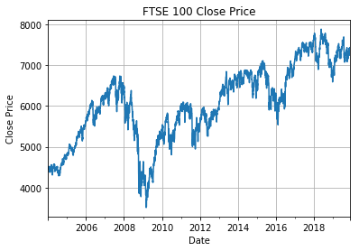

```python
# Plot the closing prices for FTSE 100
ftseTime['Close'].plot(grid = True)

plt.ylabel('Close Price')
plt.title('FTSE 100 Close Price')
plt.show()
```

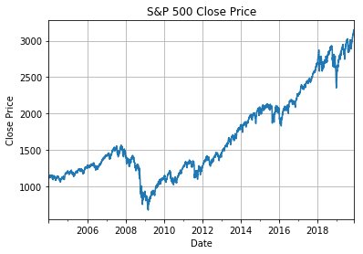

```python
# Plot the closing prices for DJIA
SP500Time['Close'].plot(grid = True)

plt.ylabel('Close Price')
plt.title('S&P 500 Close Price')
plt.show()
```

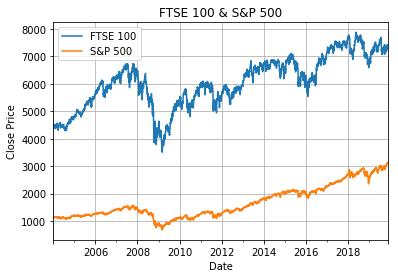

```python
#Plot both FTSE 100 and S&P500 on the same graph
ftseTime['Close'].plot(grid = True, label = "FTSE 100")
SP500Time['Close'].plot(grid = True , label = "S&P 500")

plt.ylabel('Close Price')
plt.title('FTSE 100 & S&P 500')
plt.legend()
plt.show()
```

```python
print("FTSE 100 reached an all-time high on", ftseNew.max())
```

```
FTSE 100 reached an all-time high on Date     2019-11-29 00:00:00
Close                7877.45
dtype: object
```

```python
print("FTSE 100 reached an all-time low on",ftseNew.min())
```

```
FTSE 100 reached an all-time low on Date     2004-01-02 00:00:00
Close                 3512.1
dtype: object
```

```python
print("S&P 500 reached an all-time high on", SP500New.max())
```

```
S&P 500 reached an all-time high on Date     2019-11-29 00:00:00
Close                3153.63
dtype: object
```

```python
print("S&P 500 reached an all-time low on", SP500New.min())
```

```
S&P 500 reached an all-time low on Date     2004-01-02 00:00:00
Close                 676.53
dtype: object
```

### FX Dataset

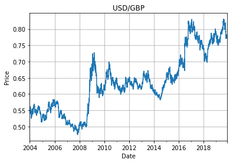

```python
# Plot the closing prices for DJIA
FXUSDTime['Price'].plot(grid = True)

plt.ylabel('Price')
plt.title('USD/GBP')
plt.show()
```

```python
print("USD/GBP exchange reached an all-time high on", FXUSDNew.max())
```

```
USD/GBP exchange reached an all-time high on Date     2019-11-29 00:00:00
Price                 0.8312
dtype: object
```

```python
print("USD/GBP exchange reached an all-time low on", FXUSDNew.min())
```

```
USD/GBP exchange reached an all-time low on Date     2004-01-01 00:00:00
Price                 0.4746
dtype: object
```

**Comments**

By plotting both indices, FTSE 100 and S&P 500 we can see that both indices suffered a large loss during the financial crisis in 2007. The indices suffered losses till 2009 which is when the markets started to slowly recover.

An additional feature needs to be introduced for the S&P 500 index in order to convert the closing price from USD to GBP.

## Feature Engineering

### News Dataset

Features to be applied to the news dataset:

- Number of words in a headline
- Number of characters in a headline
- Day when article is published
- Month when article is published
- Year when article is published
- Sentiment of headline: Positive/Negative/Neutral
- LDA topic analysis

```python
newsarticlesdf2['PublishDate'] = [d.date() for d in newsarticlesdf2['PublicationDate']]
newsarticlesdf2['PublishTime'] = [d.time() for d in newsarticlesdf2['PublicationDate']]
newsarticlesdf2.head()
```

|  | headline | body | charCount | wordcount | lastModified | publication | webPublicationDate | PublicationDate | PublishDate | PublishTime |
| --- | --- | --- | --- | --- | --- | --- | --- | --- | --- | --- |
| 0 | 8 Britons killed in South Africa road crash | Eight British tourists were killed in South Af... | 4282 | 735 | 2004-01-01T15:09:06Z | theguardian.com | 2004-01-01T15:09:06Z | 2004-01-01 15:09:06+00:00 | 2004-01-01 | 15:09:06 |
| 1 | Israeli soldier held on shooting of Briton | <b>The following correction was printed in the... | 4581 | 769 | 2017-05-08T07:32:28Z | theguardian.com | 2004-01-01T13:56:10Z | 2004-01-01 13:56:10+00:00 | 2004-01-01 | 13:56:10 |
| 2 | Aitken's Middle East foray sparked row | Jonathan Aitken so infuriated the Foreign Offi... | 2778 | 447 | 2017-05-08T07:32:29Z | theguardian.com | 2004-01-01T10:29:03Z | 2004-01-01 10:29:03+00:00 | 2004-01-01 | 10:29:03 |
| 3 | Heath feared US plan to invade Gulf | Ted Heath's government feared - at the height ... | 2270 | 364 | 2017-07-15T03:37:56Z | theguardian.com | 2004-01-01T10:27:36Z | 2004-01-01 10:27:36+00:00 | 2004-01-01 | 10:27:36 |
| 4 | Doors close on free press | A former Vietnamese journalist, Nguyen Vu Binh... | 4678 | 739 | 2004-01-02T08:25:32Z | theguardian.com | 2004-01-01T08:25:32Z | 2004-01-01 08:25:32+00:00 | 2004-01-01 | 08:25:32 |

```python
#Find day of week from the article
newsarticlesdf2['PublishDate'] = pd.to_datetime(newsarticlesdf2['PublishDate'],errors = 'coerce')
newsarticlesdf2['day_of_week'] = newsarticlesdf2['PublishDate'].dt.weekday_name
newsarticlesdf2['month'] = newsarticlesdf2['PublishDate'].dt.month
newsarticlesdf2['Month full'] = newsarticlesdf2['PublishDate'].dt.strftime('%B')
newsarticlesdf2['year'] = newsarticlesdf2['PublishDate'].dt.year
newsarticlesdf2.head()
```

|  | headline | body | charCount | wordcount | lastModified | publication | webPublicationDate | PublicationDate | PublishDate | PublishTime | day_of_week | month | Month full | year |
| --- | --- | --- | --- | --- | --- | --- | --- | --- | --- | --- | --- | --- | --- | --- |
| 0 | 8 Britons killed in South Africa road crash | Eight British tourists were killed in South Af... | 4282 | 735 | 2004-01-01T15:09:06Z | theguardian.com | 2004-01-01T15:09:06Z | 2004-01-01 15:09:06+00:00 | 2004-01-01 | 15:09:06 | Thursday | 1 | January | 2004 |
| 1 | Israeli soldier held on shooting of Briton | <b>The following correction was printed in the... | 4581 | 769 | 2017-05-08T07:32:28Z | theguardian.com | 2004-01-01T13:56:10Z | 2004-01-01 13:56:10+00:00 | 2004-01-01 | 13:56:10 | Thursday | 1 | January | 2004 |
| 2 | Aitken's Middle East foray sparked row | Jonathan Aitken so infuriated the Foreign Offi... | 2778 | 447 | 2017-05-08T07:32:29Z | theguardian.com | 2004-01-01T10:29:03Z | 2004-01-01 10:29:03+00:00 | 2004-01-01 | 10:29:03 | Thursday | 1 | January | 2004 |
| 3 | Heath feared US plan to invade Gulf | Ted Heath's government feared - at the height ... | 2270 | 364 | 2017-07-15T03:37:56Z | theguardian.com | 2004-01-01T10:27:36Z | 2004-01-01 10:27:36+00:00 | 2004-01-01 | 10:27:36 | Thursday | 1 | January | 2004 |
| 4 | Doors close on free press | A former Vietnamese journalist, Nguyen Vu Binh... | 4678 | 739 | 2004-01-02T08:25:32Z | theguardian.com | 2004-01-01T08:25:32Z | 2004-01-01 08:25:32+00:00 | 2004-01-01 | 08:25:32 | Thursday | 1 | January | 2004 |

```python
newsarticlesdf2.info()
```

```
<class 'pandas.core.frame.DataFrame'>
RangeIndex: 193068 entries, 0 to 193067
Data columns (total 14 columns):
headline              193068 non-null object
body                  193068 non-null object
charCount             193068 non-null object
wordcount             193068 non-null object
lastModified          193068 non-null object
publication           193068 non-null object
webPublicationDate    193068 non-null object
PublicationDate       193068 non-null datetime64[ns, UTC]
PublishDate           193068 non-null datetime64[ns]
PublishTime           193068 non-null object
day_of_week           193068 non-null object
month                 193068 non-null int64
Month full            193068 non-null object
year                  193068 non-null int64
dtypes: datetime64[ns, UTC](1), datetime64[ns](1), int64(2), object(10)
memory usage: 20.6+ MB
```

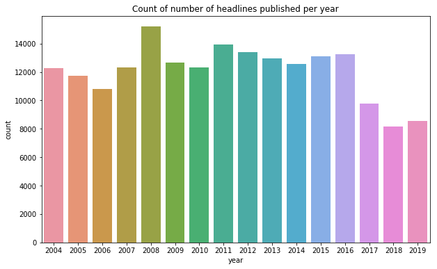

```python
plt.figure(figsize=(10,6))
sns.countplot(newsarticlesdf2['year'])
plt.title('Count of number of headlines published per year')
```

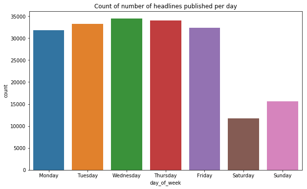

```python
plt.figure(figsize=(10,6))
sns.countplot(newsarticlesdf2['day_of_week'],order = order_days)
plt.title('Count of number of headlines published per day')
```

```python
day = newsarticlesdf2['day_of_week']
month = newsarticlesdf2['Month full']
year = newsarticlesdf2['year']

monthbyyear = newsarticlesdf2.groupby([month,year]).size()
monthbyyear = monthbyyear.rename_axis(['Month','Year']).unstack('Month').reindex(columns = order_month)
monthbyyear
```

| Month Year | January | February | March | April | May | June | July | August | September | October | November | December |
| --- | --- | --- | --- | --- | --- | --- | --- | --- | --- | --- | --- | --- |
| 2004 | 987 | 941 | 952 | 938 | 909 | 895 | 1126 | 1052 | 1152 | 1193 | 1181 | 938 |
| 2005 | 1038 | 1054 | 1146 | 1165 | 1166 | 845 | 1077 | 952 | 855 | 870 | 835 | 742 |
| 2006 | 882 | 844 | 897 | 735 | 824 | 1003 | 977 | 925 | 912 | 986 | 1028 | 801 |
| 2007 | 988 | 915 | 988 | 917 | 994 | 1040 | 1171 | 1007 | 1030 | 1200 | 1143 | 928 |
| 2008 | 1204 | 1089 | 1069 | 1296 | 1266 | 1266 | 1421 | 1160 | 1436 | 1415 | 1452 | 1128 |
| 2009 | 1348 | 1120 | 1335 | 1235 | 1194 | 1001 | 1031 | 904 | 931 | 899 | 901 | 782 |
| 2010 | 848 | 865 | 1029 | 869 | 898 | 1029 | 1110 | 1020 | 1193 | 1157 | 1235 | 1050 |
| 2011 | 1223 | 1062 | 1180 | 1007 | 1121 | 1038 | 1608 | 1160 | 1148 | 1129 | 1274 | 970 |
| 2012 | 1200 | 1184 | 1246 | 1138 | 1306 | 1080 | 1064 | 871 | 941 | 1160 | 1254 | 955 |
| 2013 | 1130 | 1047 | 1150 | 1032 | 1062 | 998 | 1094 | 1019 | 1108 | 1157 | 1145 | 1027 |
| 2014 | 1076 | 945 | 1071 | 1013 | 1089 | 1047 | 1112 | 987 | 1047 | 1126 | 1067 | 990 |
| 2015 | 1051 | 986 | 1239 | 1040 | 1061 | 1153 | 1138 | 1035 | 1190 | 1117 | 1082 | 1020 |
| 2016 | 1148 | 1143 | 1220 | 1091 | 1176 | 1205 | 1136 | 962 | 1049 | 1073 | 1141 | 894 |
| 2017 | 967 | 834 | 956 | 702 | 884 | 941 | 809 | 689 | 744 | 770 | 819 | 687 |
| 2018 | 653 | 617 | 734 | 712 | 728 | 650 | 699 | 644 | 641 | 725 | 769 | 594 |
| 2019 | 716 | 680 | 772 | 682 | 788 | 713 | 727 | 678 | 735 | 889 | 907 | 275 |

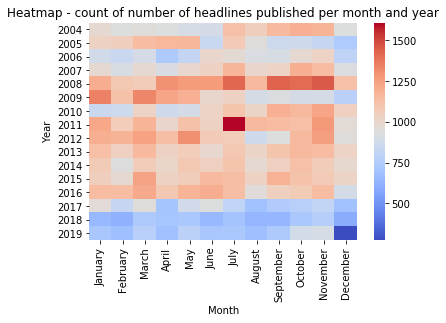

```python
sns.heatmap(monthbyyear,cmap = 'coolwarm')
plt.title('Heatmap - count of number of headlines published per month and year')
```

**Comments**  
There was a spike in the number of articles published in 2008, potentially due to the recession which occurred during 2007. The counts of articles published by year has been fairly consistent, however more recently there has been a reduction in the number of articles published especially in 2018. Splitting the publish date by day of the week shows that a lot more articles were published during the working week (Monday - Friday) and a significantly lower amount of articles published over the weekend.

July 2011 had the most articles published, potentially due to the terrorist attacks in Norway. From the heatmap above, it shows that December is normally the quieter month.

```python
#Sort the df by publish date and reset the index
newsarticlesdf2.sort_values(by = 'PublishDate',inplace = True)
newsarticlesdf2.reset_index(drop = True, inplace = True)
newsarticlesdf2.head()
```

|  | headline | body | charCount | wordcount | lastModified | publication | webPublicationDate | PublicationDate | PublishDate | PublishTime | day_of_week | month | Month full | year |
| --- | --- | --- | --- | --- | --- | --- | --- | --- | --- | --- | --- | --- | --- | --- |
| 0 | 8 Britons killed in South Africa road crash | Eight British tourists were killed in South Af... | 4282 | 735 | 2004-01-01T15:09:06Z | theguardian.com | 2004-01-01T15:09:06Z | 2004-01-01 15:09:06+00:00 | 2004-01-01 | 15:09:06 | Thursday | 1 | January | 2004 |
| 1 | Beijing bursts balloon plot | An American and a New Zealander were jailed in... | 905 | 150 | 2017-07-05T13:00:54Z | theguardian.com | 2004-01-01T01:27:50Z | 2004-01-01 01:27:50+00:00 | 2004-01-01 | 01:27:50 | Thursday | 1 | January | 2004 |
| 2 | Yangtze water plan extended | China has started building a new section of a ... | 890 | 150 | 2004-01-01T01:27:51Z | theguardian.com | 2004-01-01T01:27:51Z | 2004-01-01 01:27:51+00:00 | 2004-01-01 | 01:27:51 | Thursday | 1 | January | 2004 |
| 3 | UK feared Americans would invade Gulf during 1... | Ted Heath's government feared - at the height ... | 4350 | 705 | 2017-07-15T03:37:57Z | theguardian.com | 2004-01-01T01:28:20Z | 2004-01-01 01:28:20+00:00 | 2004-01-01 | 01:28:20 | Thursday | 1 | January | 2004 |
| 4 | In brief | <b> Baby loses fight for life</b> <br> <p>Call... | 1555 | 268 | 2004-01-01T01:28:23Z | theguardian.com | 2004-01-01T01:28:23Z | 2004-01-01 01:28:23+00:00 | 2004-01-01 | 01:28:23 | Thursday | 1 | January | 2004 |

```python
newsarticlesdf2.describe()
```

|  | month | year |
| --- | --- | --- |
| count | 193068.000000 | 193068.000000 |
| mean | 6.465743 | 2011.192740 |
| std | 3.425748 | 4.380095 |
| min | 1.000000 | 2004.000000 |
| 25% | 3.000000 | 2008.000000 |
| 50% | 6.000000 | 2011.000000 |
| 75% | 9.000000 | 2015.000000 |
| max | 12.000000 | 2019.000000 |

```python
#WordCount and Character count from the Guardian API is for the body of the text.
#Create a new column for the character and word count of the headline
newsarticlesdf2['headline_text_count'] = newsarticlesdf2['headline'].apply(lambda x: len(str(x).split(" ")))
newsarticlesdf2['headline_char_count'] = newsarticlesdf2['headline'].str.len()
newsarticlesdf2.head()
```

|  | headline | body | charCount | wordcount | lastModified | publication | webPublicationDate | PublicationDate | PublishDate | PublishTime | day_of_week | month | Month full | year | headline_text_count | headline_char_count |
| --- | --- | --- | --- | --- | --- | --- | --- | --- | --- | --- | --- | --- | --- | --- | --- | --- |
| 0 | 8 Britons killed in South Africa road crash | Eight British tourists were killed in South Af... | 4282 | 735 | 2004-01-01T15:09:06Z | theguardian.com | 2004-01-01T15:09:06Z | 2004-01-01 15:09:06+00:00 | 2004-01-01 | 15:09:06 | Thursday | 1 | January | 2004 | 8 | 43 |
| 1 | Beijing bursts balloon plot | An American and a New Zealander were jailed in... | 905 | 150 | 2017-07-05T13:00:54Z | theguardian.com | 2004-01-01T01:27:50Z | 2004-01-01 01:27:50+00:00 | 2004-01-01 | 01:27:50 | Thursday | 1 | January | 2004 | 4 | 27 |
| 2 | Yangtze water plan extended | China has started building a new section of a ... | 890 | 150 | 2004-01-01T01:27:51Z | theguardian.com | 2004-01-01T01:27:51Z | 2004-01-01 01:27:51+00:00 | 2004-01-01 | 01:27:51 | Thursday | 1 | January | 2004 | 4 | 27 |
| 3 | UK feared Americans would invade Gulf during 1... | Ted Heath's government feared - at the height ... | 4350 | 705 | 2017-07-15T03:37:57Z | theguardian.com | 2004-01-01T01:28:20Z | 2004-01-01 01:28:20+00:00 | 2004-01-01 | 01:28:20 | Thursday | 1 | January | 2004 | 10 | 60 |
| 4 | In brief | <b> Baby loses fight for life</b> <br> <p>Call... | 1555 | 268 | 2004-01-01T01:28:23Z | theguardian.com | 2004-01-01T01:28:23Z | 2004-01-01 01:28:23+00:00 | 2004-01-01 | 01:28:23 | Thursday | 1 | January | 2004 | 2 | 8 |

```python
newsarticlesdf2.describe()
```

|  | month | year | headline_text_count | headline_char_count |
| --- | --- | --- | --- | --- |
| count | 193068.000000 | 193068.000000 | 193068.000000 | 193068.000000 |
| mean | 6.465743 | 2011.192740 | 8.512457 | 51.937597 |
| std | 3.425748 | 4.380095 | 3.353998 | 20.068742 |
| min | 1.000000 | 2004.000000 | 1.000000 | 1.000000 |
| 25% | 3.000000 | 2008.000000 | 6.000000 | 37.000000 |
| 50% | 6.000000 | 2011.000000 | 9.000000 | 54.000000 |
| 75% | 9.000000 | 2015.000000 | 11.000000 | 68.000000 |
| max | 12.000000 | 2019.000000 | 30.000000 | 169.000000 |

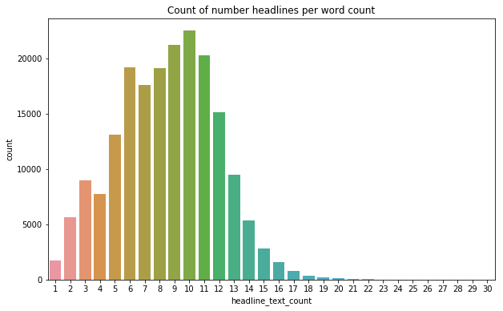

```python
plt.figure(figsize=(10,6))
sns.countplot(newsarticlesdf2['headline_text_count'])
plt.title('Count of number headlines per word count')
```

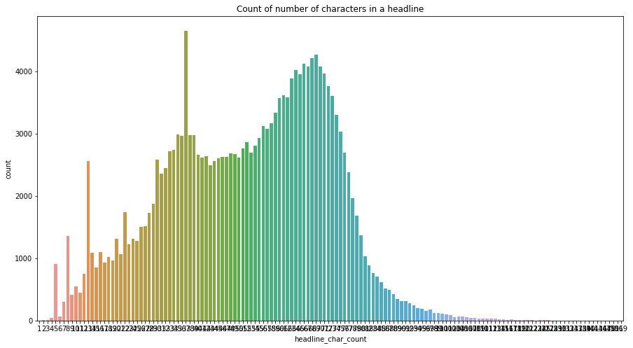

```python
plt.figure(figsize=(15,8))
sns.countplot(newsarticlesdf2['headline_char_count'])
plt.title('Count of number of characters in a headline')
```

```python
headlines_to_drop = ['Student News:','Newsdesk','in pictures','Picture desk','best photographs','world in pictures','photo highlights','Your photographs of',': 23032007','Student News','Daily Newsdesk','podcast:','StudentNews1:','News quiz:','Helen Boden:','Milling Around','52 weeks:','Underwater photography:','The Illustrated London News','Photo highlights','picture of the day','photo of the day','Eyewitness:','photographer of the year','Video:',' photographs of the day','video:','pictures of the day','Xan Brooks','Activate 2011:','Media Talk:','MediaTalk:','Mediatalk:','Media talk:','In pictures:','365 days:','366 days','The Guardian Essential Report','Mediatalk','MediaTalk','quiz:','tweets:','weekly:','Weekly:','quiz of']
newsarticlesdf3 = newsarticlesdf2[~newsarticlesdf2.headline.str.contains('|'.join(headlines_to_drop))]
```

```python
newsarticlesdf3.shape
```

```
(191648, 16)
```

**Comments**  
Remove the above words listed in headlines_to_drop as these headlines may not have an impact on the stock market. In order to precisely forecast the stock price using the news articles containing photos, image processing could be used to see what photos were released.

```python
#Remove time zone from the datetime column - can't export file where timezones are present - not supported by excel.
newsarticlesdf3['PublicationDate']= newsarticlesdf3['PublicationDate'].dt.tz_localize(None)
```

```python
newsarticlesdf3.head()
```

|  | headline | body | charCount | wordcount | lastModified | publication | webPublicationDate | PublicationDate | PublishDate | PublishTime | day_of_week | month | Month full | year | headline_text_count | headline_char_count |
| --- | --- | --- | --- | --- | --- | --- | --- | --- | --- | --- | --- | --- | --- | --- | --- | --- |
| 0 | 8 Britons killed in South Africa road crash | Eight British tourists were killed in South Af... | 4282 | 735 | 2004-01-01T15:09:06Z | theguardian.com | 2004-01-01T15:09:06Z | 2004-01-01 15:09:06 | 2004-01-01 | 15:09:06 | Thursday | 1 | January | 2004 | 8 | 43 |
| 1 | Beijing bursts balloon plot | An American and a New Zealander were jailed in... | 905 | 150 | 2017-07-05T13:00:54Z | theguardian.com | 2004-01-01T01:27:50Z | 2004-01-01 01:27:50 | 2004-01-01 | 01:27:50 | Thursday | 1 | January | 2004 | 4 | 27 |
| 2 | Yangtze water plan extended | China has started building a new section of a ... | 890 | 150 | 2004-01-01T01:27:51Z | theguardian.com | 2004-01-01T01:27:51Z | 2004-01-01 01:27:51 | 2004-01-01 | 01:27:51 | Thursday | 1 | January | 2004 | 4 | 27 |
| 3 | UK feared Americans would invade Gulf during 1... | Ted Heath's government feared - at the height ... | 4350 | 705 | 2017-07-15T03:37:57Z | theguardian.com | 2004-01-01T01:28:20Z | 2004-01-01 01:28:20 | 2004-01-01 | 01:28:20 | Thursday | 1 | January | 2004 | 10 | 60 |
| 4 | In brief | <b> Baby loses fight for life</b> <br> <p>Call... | 1555 | 268 | 2004-01-01T01:28:23Z | theguardian.com | 2004-01-01T01:28:23Z | 2004-01-01 01:28:23 | 2004-01-01 | 01:28:23 | Thursday | 1 | January | 2004 | 2 | 8 |

```python
newsarticlesdf4 = newsarticlesdf3
newsarticlesdf4.shape
```

```
(191648, 16)
```

```python
newsarticlesdf4['wordcount'].unique()
```

```
array(['735', '150', '705', ..., '6156', '9353', '9402'], dtype=object)
```

```python
#newsarticlesdf4.to_excel('newsarticlesdf4.xlsx')
```

```python
#newsarticlesdf4 = pd.read_excel('newsarticlesdf4.xlsx')
```

```python
newsarticlesdf4.shape
```

```
(191648, 16)
```

```python
newsarticlesdf4.info()
```

```
<class 'pandas.core.frame.DataFrame'>
Int64Index: 191648 entries, 0 to 193067
Data columns (total 16 columns):
headline               191648 non-null object
body                   191648 non-null object
charCount              191648 non-null object
wordcount              191648 non-null object
lastModified           191648 non-null object
publication            191648 non-null object
webPublicationDate     191648 non-null object
PublicationDate        191648 non-null datetime64[ns]
PublishDate            191648 non-null datetime64[ns]
PublishTime            191648 non-null object
day_of_week            191648 non-null object
month                  191648 non-null int64
Month full             191648 non-null object
year                   191648 non-null int64
headline_text_count    191648 non-null int64
headline_char_count    191648 non-null int64
dtypes: datetime64[ns](2), int64(4), object(10)
memory usage: 24.9+ MB
```

```python
newsarticlesdf4['headline'] = newsarticlesdf4['headline'].astype('str')
newsarticlesdf4['body']=newsarticlesdf4['body'].astype('str')
```

```python
from wordcloud import WordCloud, STOPWORDS,ImageColorGenerator
from nltk import word_tokenize, sent_tokenize
from nltk.corpus import stopwords
from nltk.stem import LancasterStemmer, WordNetLemmatizer, PorterStemmer
from textblob import TextBlob
from PIL import Image
from os import path
```

#### Clean text in body

```python
#code adapted from Data Science Blog [24]
#remove <br> </br> <p> </p> <b> </b> - html tags which were present in the body
newsarticlesdf4 = newsarticlesdf4.replace('<br>', '',regex = True)
newsarticlesdf4 = newsarticlesdf4.replace('</br>', '',regex = True)
newsarticlesdf4 = newsarticlesdf4.replace('<b>', '',regex = True)
newsarticlesdf4 = newsarticlesdf4.replace('</b>', '',regex = True)
newsarticlesdf4 = newsarticlesdf4.replace('<p>', '',regex = True)
newsarticlesdf4 = newsarticlesdf4.replace('</p>', '',regex = True)
newsarticlesdf4.head()
```

|  | headline | body | charCount | wordcount | lastModified | publication | webPublicationDate | PublicationDate | PublishDate | PublishTime | day_of_week | month | Month full | year | headline_text_count | headline_char_count |
| --- | --- | --- | --- | --- | --- | --- | --- | --- | --- | --- | --- | --- | --- | --- | --- | --- |
| 0 | 8 Britons killed in South Africa road crash | Eight British tourists were killed in South Af... | 4282 | 735 | 2004-01-01T15:09:06Z | theguardian.com | 2004-01-01T15:09:06Z | 2004-01-01 15:09:06 | 2004-01-01 | 15:09:06 | Thursday | 1 | January | 2004 | 8 | 43 |
| 1 | Beijing bursts balloon plot | An American and a New Zealander were jailed in... | 905 | 150 | 2017-07-05T13:00:54Z | theguardian.com | 2004-01-01T01:27:50Z | 2004-01-01 01:27:50 | 2004-01-01 | 01:27:50 | Thursday | 1 | January | 2004 | 4 | 27 |
| 2 | Yangtze water plan extended | China has started building a new section of a ... | 890 | 150 | 2004-01-01T01:27:51Z | theguardian.com | 2004-01-01T01:27:51Z | 2004-01-01 01:27:51 | 2004-01-01 | 01:27:51 | Thursday | 1 | January | 2004 | 4 | 27 |
| 3 | UK feared Americans would invade Gulf during 1... | Ted Heath's government feared - at the height ... | 4350 | 705 | 2017-07-15T03:37:57Z | theguardian.com | 2004-01-01T01:28:20Z | 2004-01-01 01:28:20 | 2004-01-01 | 01:28:20 | Thursday | 1 | January | 2004 | 10 | 60 |
| 4 | In brief | Baby loses fight for life Callum Taylor, an ... | 1555 | 268 | 2004-01-01T01:28:23Z | theguardian.com | 2004-01-01T01:28:23Z | 2004-01-01 01:28:23 | 2004-01-01 | 01:28:23 | Thursday | 1 | January | 2004 | 2 | 8 |

```python
#Use newsarticlesdf4 which contains headlines and body text
#convert text to lowercase
newsarticlesdf4['headline_clean'] = newsarticlesdf4['headline'].apply(lambda x: " ".join(x.lower() for x in x.split()))
newsarticlesdf4['body_clean'] = newsarticlesdf4['body'].apply(lambda x: " ".join(x.lower() for x in x.split()))
newsarticlesdf4.head()
```

|  | headline | body | charCount | wordcount | lastModified | publication | webPublicationDate | PublicationDate | PublishDate | PublishTime | day_of_week | month | Month full | year | headline_text_count | headline_char_count | headline_clean | body_clean |
| --- | --- | --- | --- | --- | --- | --- | --- | --- | --- | --- | --- | --- | --- | --- | --- | --- | --- | --- |
| 0 | 8 Britons killed in South Africa road crash | Eight British tourists were killed in South Af... | 4282 | 735 | 2004-01-01T15:09:06Z | theguardian.com | 2004-01-01T15:09:06Z | 2004-01-01 15:09:06 | 2004-01-01 | 15:09:06 | Thursday | 1 | January | 2004 | 8 | 43 | 8 britons killed in south africa road crash | eight british tourists were killed in south af... |
| 1 | Beijing bursts balloon plot | An American and a New Zealander were jailed in... | 905 | 150 | 2017-07-05T13:00:54Z | theguardian.com | 2004-01-01T01:27:50Z | 2004-01-01 01:27:50 | 2004-01-01 | 01:27:50 | Thursday | 1 | January | 2004 | 4 | 27 | beijing bursts balloon plot | an american and a new zealander were jailed in... |
| 2 | Yangtze water plan extended | China has started building a new section of a ... | 890 | 150 | 2004-01-01T01:27:51Z | theguardian.com | 2004-01-01T01:27:51Z | 2004-01-01 01:27:51 | 2004-01-01 | 01:27:51 | Thursday | 1 | January | 2004 | 4 | 27 | yangtze water plan extended | china has started building a new section of a ... |
| 3 | UK feared Americans would invade Gulf during 1... | Ted Heath's government feared - at the height ... | 4350 | 705 | 2017-07-15T03:37:57Z | theguardian.com | 2004-01-01T01:28:20Z | 2004-01-01 01:28:20 | 2004-01-01 | 01:28:20 | Thursday | 1 | January | 2004 | 10 | 60 | uk feared americans would invade gulf during 1... | ted heath's government feared - at the height ... |
| 4 | In brief | Baby loses fight for life Callum Taylor, an ... | 1555 | 268 | 2004-01-01T01:28:23Z | theguardian.com | 2004-01-01T01:28:23Z | 2004-01-01 01:28:23 | 2004-01-01 | 01:28:23 | Thursday | 1 | January | 2004 | 2 | 8 | in brief | baby loses fight for life callum taylor, an ei... |

```python
#remove special characters from the text
newsarticlesdf4['headline_clean'] = newsarticlesdf4['headline_clean'].str.replace('[^\w\s]','')
newsarticlesdf4['body_clean'] = newsarticlesdf4['body_clean'].str.replace('[^\w\s]','')
newsarticlesdf4.head()
```

|  | headline | body | charCount | wordcount | lastModified | publication | webPublicationDate | PublicationDate | PublishDate | PublishTime | day_of_week | month | Month full | year | headline_text_count | headline_char_count | headline_clean | body_clean |
| --- | --- | --- | --- | --- | --- | --- | --- | --- | --- | --- | --- | --- | --- | --- | --- | --- | --- | --- |
| 0 | 8 Britons killed in South Africa road crash | Eight British tourists were killed in South Af... | 4282 | 735 | 2004-01-01T15:09:06Z | theguardian.com | 2004-01-01T15:09:06Z | 2004-01-01 15:09:06 | 2004-01-01 | 15:09:06 | Thursday | 1 | January | 2004 | 8 | 43 | 8 britons killed in south africa road crash | eight british tourists were killed in south af... |
| 1 | Beijing bursts balloon plot | An American and a New Zealander were jailed in... | 905 | 150 | 2017-07-05T13:00:54Z | theguardian.com | 2004-01-01T01:27:50Z | 2004-01-01 01:27:50 | 2004-01-01 | 01:27:50 | Thursday | 1 | January | 2004 | 4 | 27 | beijing bursts balloon plot | an american and a new zealander were jailed in... |
| 2 | Yangtze water plan extended | China has started building a new section of a ... | 890 | 150 | 2004-01-01T01:27:51Z | theguardian.com | 2004-01-01T01:27:51Z | 2004-01-01 01:27:51 | 2004-01-01 | 01:27:51 | Thursday | 1 | January | 2004 | 4 | 27 | yangtze water plan extended | china has started building a new section of a ... |
| 3 | UK feared Americans would invade Gulf during 1... | Ted Heath's government feared - at the height ... | 4350 | 705 | 2017-07-15T03:37:57Z | theguardian.com | 2004-01-01T01:28:20Z | 2004-01-01 01:28:20 | 2004-01-01 | 01:28:20 | Thursday | 1 | January | 2004 | 10 | 60 | uk feared americans would invade gulf during 1... | ted heaths government feared at the height of... |
| 4 | In brief | Baby loses fight for life Callum Taylor, an ... | 1555 | 268 | 2004-01-01T01:28:23Z | theguardian.com | 2004-01-01T01:28:23Z | 2004-01-01 01:28:23 | 2004-01-01 | 01:28:23 | Thursday | 1 | January | 2004 | 2 | 8 | in brief | baby loses fight for life callum taylor an eig... |

```python
#Stopwords - remove stop words
stop = stopwords.words('english') #includes words such as I,my,we
#Extend the stop words to remove the below. These words will appear a lot in the headlines, which means
#we would not be able to see the more important words in the headlines
stop.extend(['news','new','from', 'subject', 're', 'edu', 'use', 'not', 'would', 'say', 'could', '_', 'be', 'know', 'good', 'go', 'get', 'do', 'done', 'try', 'many', 'some', 'nice', 'thank', 'think', 'see', 'rather', 'easy', 'easily', 'lot', 'lack', 'make', 'want', 'seem', 'run', 'need', 'even', 'right', 'line', 'even', 'also', 'may', 'take', 'come','media','photo','photography','bn'])
newsarticlesdf4['headline_clean_stop'] = newsarticlesdf4['headline_clean'].apply(lambda x: " ".join(x for x in x.split() if x not in stop))
newsarticlesdf4['body_clean_stop'] = newsarticlesdf4['body_clean'].apply(lambda x: " ".join(x for x in x.split() if x not in stop))

newsarticlesdf4.head()
```

|  | headline | body | charCount | wordcount | lastModified | publication | webPublicationDate | PublicationDate | PublishDate | PublishTime | day_of_week | month | Month full | year | headline_text_count | headline_char_count | headline_clean | body_clean | headline_clean_stop | body_clean_stop |
| --- | --- | --- | --- | --- | --- | --- | --- | --- | --- | --- | --- | --- | --- | --- | --- | --- | --- | --- | --- | --- |
| 0 | 8 Britons killed in South Africa road crash | Eight British tourists were killed in South Af... | 4282 | 735 | 2004-01-01T15:09:06Z | theguardian.com | 2004-01-01T15:09:06Z | 2004-01-01 15:09:06 | 2004-01-01 | 15:09:06 | Thursday | 1 | January | 2004 | 8 | 43 | 8 britons killed in south africa road crash | eight british tourists were killed in south af... | 8 britons killed south africa road crash | eight british tourists killed south africa min... |
| 1 | Beijing bursts balloon plot | An American and a New Zealander were jailed in... | 905 | 150 | 2017-07-05T13:00:54Z | theguardian.com | 2004-01-01T01:27:50Z | 2004-01-01 01:27:50 | 2004-01-01 | 01:27:50 | Thursday | 1 | January | 2004 | 4 | 27 | beijing bursts balloon plot | an american and a new zealander were jailed in... | beijing bursts balloon plot | american zealander jailed beijing yesterday ch... |
| 2 | Yangtze water plan extended | China has started building a new section of a ... | 890 | 150 | 2004-01-01T01:27:51Z | theguardian.com | 2004-01-01T01:27:51Z | 2004-01-01 01:27:51 | 2004-01-01 | 01:27:51 | Thursday | 1 | January | 2004 | 4 | 27 | yangtze water plan extended | china has started building a new section of a ... | yangtze water plan extended | china started building section multibillionpou... |
| 3 | UK feared Americans would invade Gulf during 1... | Ted Heath's government feared - at the height ... | 4350 | 705 | 2017-07-15T03:37:57Z | theguardian.com | 2004-01-01T01:28:20Z | 2004-01-01 01:28:20 | 2004-01-01 | 01:28:20 | Thursday | 1 | January | 2004 | 10 | 60 | uk feared americans would invade gulf during 1... | ted heaths government feared at the height of... | uk feared americans invade gulf 1973 oil crisis | ted heaths government feared height 1973 oil c... |
| 4 | In brief | Baby loses fight for life Callum Taylor, an ... | 1555 | 268 | 2004-01-01T01:28:23Z | theguardian.com | 2004-01-01T01:28:23Z | 2004-01-01 01:28:23 | 2004-01-01 | 01:28:23 | Thursday | 1 | January | 2004 | 2 | 8 | in brief | baby loses fight for life callum taylor an eig... | brief | baby loses fight life callum taylor eightmonth... |

```python
#Create word cloud
text = " ".join(headlines for headlines in newsarticlesdf4.headline)
print ("There are {} words in the combination of all headlines.".format(len(text)))
```

```
There are 10150199 words in the combination of all headlines.
```

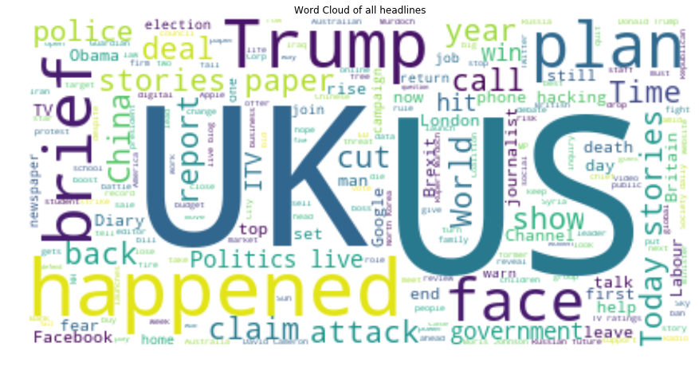

```python
stopwords = ['BBC','say','new','News','media','Today','will','ad','says','news','from', 'subject', 're', 'edu', 'use', 'not', 'would', 'say', 'could', '_', 'be', 'know', 'good', 'go', 'get', 'do', 'done', 'try', 'many', 'some', 'nice', 'thank', 'think', 'see', 'rather', 'easy', 'easily', 'lot', 'lack', 'make', 'want', 'seem', 'run', 'need', 'even', 'right', 'line', 'even', 'also', 'may', 'take', 'come','media','photo','photography','bn'] + list(STOPWORDS)
wordcloud = WordCloud(stopwords=stopwords, background_color="white").generate(text)

plt.figure(figsize = (15,10))
plt.imshow(wordcloud, interpolation='bilinear')
plt.axis("off")
plt.title('Word Cloud of all headlines')
plt.show()
```

The time series plots of the FTSE 100 show four distinct periods, hence investigate the words presents for these periods:

- 2004 - 2007
- 2008 - 2009
- 2010 - 2015
- 2016 - Today

```python
news2004 = newsarticlesdf4.loc[(newsarticlesdf4['year']>= 2004) &(newsarticlesdf4['year']<= 2007)]
news2008 = newsarticlesdf4.loc[(newsarticlesdf4['year']>= 2008) &(newsarticlesdf4['year']<= 2009)]
news2010 = newsarticlesdf4.loc[(newsarticlesdf4['year']>= 2010) &(newsarticlesdf4['year']<= 2015)]
news2016 = newsarticlesdf4.loc[(newsarticlesdf4['year']>= 2016) &(newsarticlesdf4['year']<= 2019)]
```

```python
#Create word cloud
text2004 = " ".join(headlines for headlines in news2004.headline)
print ("There are {} words in the combination of all headlines from 2004 to 2007.".format(len(text2004)))
```

```
There are 1625266 words in the combination of all headlines from 2004 to 2007.
```

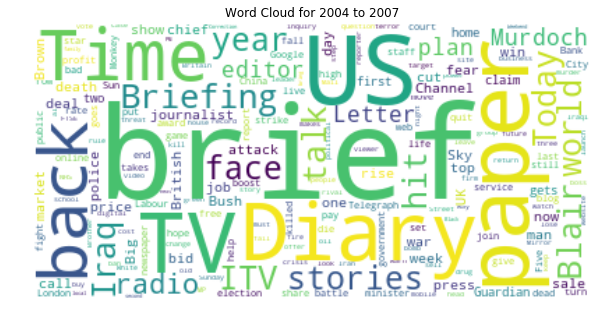

```python
wordcloud2004 = WordCloud(stopwords=stopwords, background_color="white", collocations = False).generate(text2004)

plt.figure(figsize = (10,10))
plt.imshow(wordcloud2004, interpolation='bilinear')
plt.axis("off")
plt.title('Word Cloud for 2004 to 2007')
plt.show()
```

```python
#Create word cloud
text2008 = " ".join(headlines for headlines in news2008.headline)
print ("There are {} words in the combination of all headlines from 2008 to 2009.".format(len(text2008)))
```

```
There are 1263945 words in the combination of all headlines from 2008 to 2009.
```

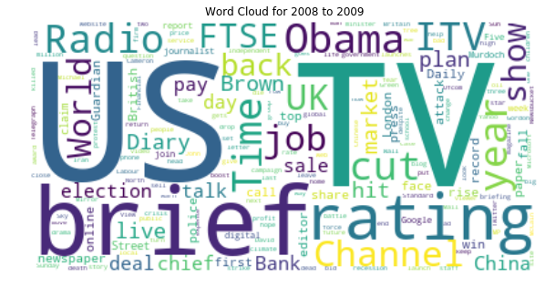

```python
wordcloud2008 = WordCloud(stopwords=stopwords, background_color="white", collocations = False).generate(text2008)

plt.figure(figsize = (10,10))
plt.imshow(wordcloud2008, interpolation='bilinear')
plt.axis("off")
plt.title('Word Cloud for 2008 to 2009')
plt.show()
```

```python
#Create word cloud
text2010 = " ".join(headlines for headlines in news2010.headline)
print ("There are {} words in the combination of all headlines from 2010 to 2015.".format(len(text2010)))
```

```
There are 4560658 words in the combination of all headlines from 2010 to 2015.
```

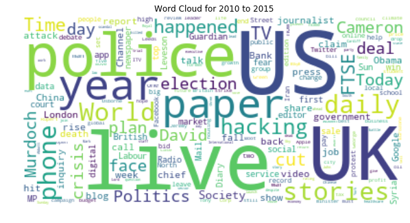

```python
wordcloud2010 = WordCloud(stopwords=stopwords, background_color="white", collocations = False).generate(text2010)

plt.figure(figsize = (10,10))
plt.imshow(wordcloud2010, interpolation='bilinear')
plt.axis("off")
plt.title('Word Cloud for 2010 to 2015')
plt.show()
```

```python
#Create word cloud
text2016 = " ".join(headlines for headlines in news2016.headline)
print ("There are {} words in the combination of all headlines from 2016 to present.".format(len(text2010)))
```

```
There are 4560658 words in the combination of all headlines from 2016 to present.
```

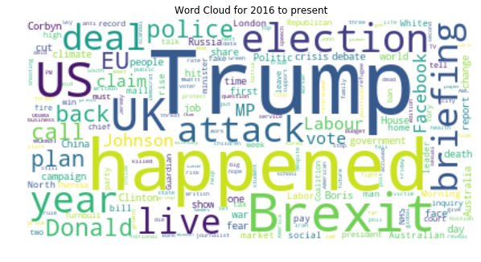

```python
wordcloud2016 = WordCloud(stopwords=stopwords, background_color="white", collocations = False).generate(text2016)

plt.figure(figsize = (10,10))
plt.imshow(wordcloud2016, interpolation='bilinear')
plt.axis("off")
plt.title('Word Cloud for 2016 to present')
plt.show()
```

**Comments**

There are four distinct periods when looking at the stock indices graphs

- 2004 - 2007
- 2008 - 2009 - Recession
- 2010 - 2015 - The economy started recovering
- 2016 to present - Brexit

With these distinct periods we can see the most common words from the word clouds. For example in the period 2016 to present, major events occured such as Trump becoming president of USA, Brexit in the UK, Facebook appearing in the news due to privacy. 2008 - 2009 there was a lot of focus on the economy crashing with words such as 'rating','fall','market','cut','bank'.

#### Text Blob

```python
#text blob, code adapted from Susan Li [31]

def detect_polarity(text):
    return TextBlob(text).sentiment.polarity
newsarticlesdf4['polarity_headline'] = newsarticlesdf4.headline_clean_stop.apply(detect_polarity)
newsarticlesdf4['polarity_body'] = newsarticlesdf4.body_clean_stop.apply(detect_polarity)
newsarticlesdf4.head()
```

|  | headline | body | charCount | wordcount | lastModified | publication | webPublicationDate | PublicationDate | PublishDate | PublishTime | ... | Month full | year | headline_text_count | headline_char_count | headline_clean | body_clean | headline_clean_stop | body_clean_stop | polarity_headline | polarity_body |
| --- | --- | --- | --- | --- | --- | --- | --- | --- | --- | --- | --- | --- | --- | --- | --- | --- | --- | --- | --- | --- | --- |
| 0 | 8 Britons killed in South Africa road crash | Eight British tourists were killed in South Af... | 4282 | 735 | 2004-01-01T15:09:06Z | theguardian.com | 2004-01-01T15:09:06Z | 2004-01-01 15:09:06 | 2004-01-01 | 15:09:06 | ... | January | 2004 | 8 | 43 | 8 britons killed in south africa road crash | eight british tourists were killed in south af... | 8 britons killed south africa road crash | eight british tourists killed south africa min... | -0.2 | -0.028259 |
| 1 | Beijing bursts balloon plot | An American and a New Zealander were jailed in... | 905 | 150 | 2017-07-05T13:00:54Z | theguardian.com | 2004-01-01T01:27:50Z | 2004-01-01 01:27:50 | 2004-01-01 | 01:27:50 | ... | January | 2004 | 4 | 27 | beijing bursts balloon plot | an american and a new zealander were jailed in... | beijing bursts balloon plot | american zealander jailed beijing yesterday ch... | 0.0 | -0.087500 |
| 2 | Yangtze water plan extended | China has started building a new section of a ... | 890 | 150 | 2004-01-01T01:27:51Z | theguardian.com | 2004-01-01T01:27:51Z | 2004-01-01 01:27:51 | 2004-01-01 | 01:27:51 | ... | January | 2004 | 4 | 27 | yangtze water plan extended | china has started building a new section of a ... | yangtze water plan extended | china started building section multibillionpou... | 0.0 | 0.109259 |
| 3 | UK feared Americans would invade Gulf during 1... | Ted Heath's government feared - at the height ... | 4350 | 705 | 2017-07-15T03:37:57Z | theguardian.com | 2004-01-01T01:28:20Z | 2004-01-01 01:28:20 | 2004-01-01 | 01:28:20 | ... | January | 2004 | 10 | 60 | uk feared americans would invade gulf during 1... | ted heaths government feared at the height of... | uk feared americans invade gulf 1973 oil crisis | ted heaths government feared height 1973 oil c... | 0.0 | 0.035663 |
| 4 | In brief | Baby loses fight for life Callum Taylor, an ... | 1555 | 268 | 2004-01-01T01:28:23Z | theguardian.com | 2004-01-01T01:28:23Z | 2004-01-01 01:28:23 | 2004-01-01 | 01:28:23 | ... | January | 2004 | 2 | 8 | in brief | baby loses fight for life callum taylor an eig... | brief | baby loses fight life callum taylor eightmonth... | 0.0 | 0.021795 |

5 rows × 22 columns

```python
def detect_subjectivity(text):
    return TextBlob(text).sentiment.subjectivity
newsarticlesdf4['subjectivity_headline'] = newsarticlesdf4.headline_clean_stop.apply(detect_subjectivity)
newsarticlesdf4['subjectivity_body'] = newsarticlesdf4.body_clean_stop.apply(detect_subjectivity)
newsarticlesdf4.head()
```

|  | headline | body | charCount | wordcount | lastModified | publication | webPublicationDate | PublicationDate | PublishDate | PublishTime | ... | headline_text_count | headline_char_count | headline_clean | body_clean | headline_clean_stop | body_clean_stop | polarity_headline | polarity_body | subjectivity_headline | subjectivity_body |
| --- | --- | --- | --- | --- | --- | --- | --- | --- | --- | --- | --- | --- | --- | --- | --- | --- | --- | --- | --- | --- | --- |
| 0 | 8 Britons killed in South Africa road crash | Eight British tourists were killed in South Af... | 4282 | 735 | 2004-01-01T15:09:06Z | theguardian.com | 2004-01-01T15:09:06Z | 2004-01-01 15:09:06 | 2004-01-01 | 15:09:06 | ... | 8 | 43 | 8 britons killed in south africa road crash | eight british tourists were killed in south af... | 8 britons killed south africa road crash | eight british tourists killed south africa min... | -0.2 | -0.028259 | 0.000000 | 0.287704 |
| 1 | Beijing bursts balloon plot | An American and a New Zealander were jailed in... | 905 | 150 | 2017-07-05T13:00:54Z | theguardian.com | 2004-01-01T01:27:50Z | 2004-01-01 01:27:50 | 2004-01-01 | 01:27:50 | ... | 4 | 27 | beijing bursts balloon plot | an american and a new zealander were jailed in... | beijing bursts balloon plot | american zealander jailed beijing yesterday ch... | 0.0 | -0.087500 | 0.000000 | 0.154167 |
| 2 | Yangtze water plan extended | China has started building a new section of a ... | 890 | 150 | 2004-01-01T01:27:51Z | theguardian.com | 2004-01-01T01:27:51Z | 2004-01-01 01:27:51 | 2004-01-01 | 01:27:51 | ... | 4 | 27 | yangtze water plan extended | china has started building a new section of a ... | yangtze water plan extended | china started building section multibillionpou... | 0.0 | 0.109259 | 0.000000 | 0.481481 |
| 3 | UK feared Americans would invade Gulf during 1... | Ted Heath's government feared - at the height ... | 4350 | 705 | 2017-07-15T03:37:57Z | theguardian.com | 2004-01-01T01:28:20Z | 2004-01-01 01:28:20 | 2004-01-01 | 01:28:20 | ... | 10 | 60 | uk feared americans would invade gulf during 1... | ted heaths government feared at the height of... | uk feared americans invade gulf 1973 oil crisis | ted heaths government feared height 1973 oil c... | 0.0 | 0.035663 | 0.000000 | 0.343582 |
| 4 | In brief | Baby loses fight for life Callum Taylor, an ... | 1555 | 268 | 2004-01-01T01:28:23Z | theguardian.com | 2004-01-01T01:28:23Z | 2004-01-01 01:28:23 | 2004-01-01 | 01:28:23 | ... | 2 | 8 | in brief | baby loses fight for life callum taylor an eig... | brief | baby loses fight life callum taylor eightmonth... | 0.0 | 0.021795 | 0.333333 | 0.242308 |

5 rows × 24 columns

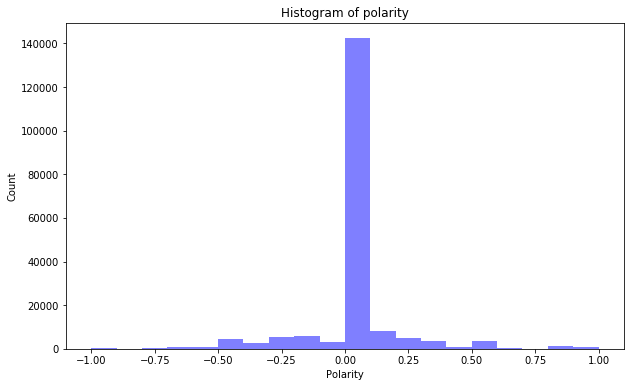

```python
#Distribution of Polarity
num_bins = 20
plt.figure(figsize=(10,6))
n, bins, patches = plt.hist(newsarticlesdf4.polarity_headline, num_bins, facecolor='blue', alpha=0.5)
plt.xlabel('Polarity')
plt.ylabel('Count')
plt.title('Histogram of polarity')
plt.show();
```

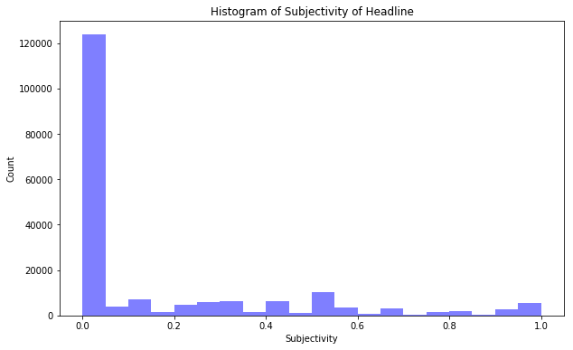

```python
#Distribution of subjectivity headline
num_bins = 20
plt.figure(figsize=(10,6))
n, bins, patches = plt.hist(newsarticlesdf4.subjectivity_headline, num_bins, facecolor='blue', alpha=0.5)
plt.xlabel('Subjectivity')
plt.ylabel('Count')
plt.title('Histogram of Subjectivity of Headline')
plt.show();
```

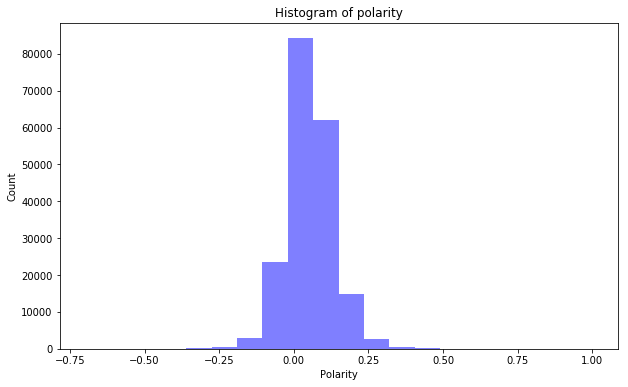

```python
#Distribution of Polarity
num_bins = 20
plt.figure(figsize=(10,6))
n, bins, patches = plt.hist(newsarticlesdf4.polarity_body, num_bins, facecolor='blue', alpha=0.5)
plt.xlabel('Polarity')
plt.ylabel('Count')
plt.title('Histogram of polarity')
plt.show();
```

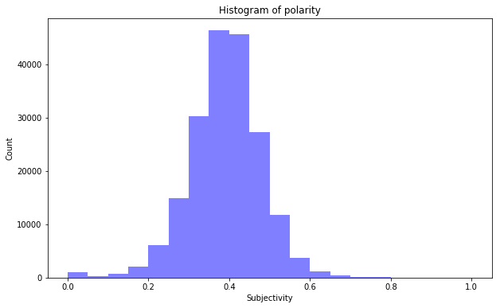

```python
#Distribution of subjectivity of body
num_bins = 20
plt.figure(figsize=(10,6))
n, bins, patches = plt.hist(newsarticlesdf4.subjectivity_body, num_bins, facecolor='blue', alpha=0.5)
plt.xlabel('Subjectivity')
plt.ylabel('Count')
plt.title('Histogram of polarity')
plt.show();
```

**Comments**  
TextBlob does not show any meaningful results for the sentiment of the headline. A number of articles have been classified as neutral when they should not be. VADER will be used instead to calculate the sentiment of the headline. TextBlob show some results for the sentiment of the body of the article, however due to computational resources, the body of the article is not in the scope of this investigation.

#### VADER

```python
#Import vader package
from vaderSentiment.vaderSentiment import SentimentIntensityAnalyzer
analyzer = SentimentIntensityAnalyzer()
```

```python
#apply vader sentiment to output columns neg,pos,neu and compound. Code adapted from [27]
sentiment = newsarticlesdf4['headline'].apply(lambda x: analyzer.polarity_scores(x))
newsarticlesdf4 = pd.concat([newsarticlesdf4,sentiment.apply(pd.Series)],1)
newsarticlesdf4.head()
```

|  | headline | body | charCount | wordcount | lastModified | publication | webPublicationDate | PublicationDate | PublishDate | PublishTime | ... | headline_clean_stop | body_clean_stop | polarity_headline | polarity_body | subjectivity_headline | subjectivity_body | neg | neu | pos | compound |
| --- | --- | --- | --- | --- | --- | --- | --- | --- | --- | --- | --- | --- | --- | --- | --- | --- | --- | --- | --- | --- | --- |
| 0 | 8 Britons killed in South Africa road crash | Eight British tourists were killed in South Af... | 4282 | 735 | 2004-01-01T15:09:06Z | theguardian.com | 2004-01-01T15:09:06Z | 2004-01-01 15:09:06 | 2004-01-01 | 15:09:06 | ... | 8 britons killed south africa road crash | eight british tourists killed south africa min... | -0.2 | -0.028259 | 0.000000 | 0.287704 | 0.590 | 0.410 | 0.0 | -0.8020 |
| 1 | Beijing bursts balloon plot | An American and a New Zealander were jailed in... | 905 | 150 | 2017-07-05T13:00:54Z | theguardian.com | 2004-01-01T01:27:50Z | 2004-01-01 01:27:50 | 2004-01-01 | 01:27:50 | ... | beijing bursts balloon plot | american zealander jailed beijing yesterday ch... | 0.0 | -0.087500 | 0.000000 | 0.154167 | 0.000 | 1.000 | 0.0 | 0.0000 |
| 2 | Yangtze water plan extended | China has started building a new section of a ... | 890 | 150 | 2004-01-01T01:27:51Z | theguardian.com | 2004-01-01T01:27:51Z | 2004-01-01 01:27:51 | 2004-01-01 | 01:27:51 | ... | yangtze water plan extended | china started building section multibillionpou... | 0.0 | 0.109259 | 0.000000 | 0.481481 | 0.000 | 1.000 | 0.0 | 0.0000 |
| 3 | UK feared Americans would invade Gulf during 1... | Ted Heath's government feared - at the height ... | 4350 | 705 | 2017-07-15T03:37:57Z | theguardian.com | 2004-01-01T01:28:20Z | 2004-01-01 01:28:20 | 2004-01-01 | 01:28:20 | ... | uk feared americans invade gulf 1973 oil crisis | ted heaths government feared height 1973 oil c... | 0.0 | 0.035663 | 0.000000 | 0.343582 | 0.477 | 0.523 | 0.0 | -0.8074 |
| 4 | In brief | Baby loses fight for life Callum Taylor, an ... | 1555 | 268 | 2004-01-01T01:28:23Z | theguardian.com | 2004-01-01T01:28:23Z | 2004-01-01 01:28:23 | 2004-01-01 | 01:28:23 | ... | brief | baby loses fight life callum taylor eightmonth... | 0.0 | 0.021795 | 0.333333 | 0.242308 | 0.000 | 1.000 | 0.0 | 0.0000 |

5 rows × 28 columns

```python
#Drop neg neu and pos column from the dataset, only interested in the Compound sentiment analysis score
newsarticlesdf4 = newsarticlesdf4.drop(['neg','neu','pos'],axis = 1)
newsarticlesdf4.head()
```

|  | headline | body | charCount | wordcount | lastModified | publication | webPublicationDate | PublicationDate | PublishDate | PublishTime | ... | headline_char_count | headline_clean | body_clean | headline_clean_stop | body_clean_stop | polarity_headline | polarity_body | subjectivity_headline | subjectivity_body | compound |
| --- | --- | --- | --- | --- | --- | --- | --- | --- | --- | --- | --- | --- | --- | --- | --- | --- | --- | --- | --- | --- | --- |
| 0 | 8 Britons killed in South Africa road crash | Eight British tourists were killed in South Af... | 4282 | 735 | 2004-01-01T15:09:06Z | theguardian.com | 2004-01-01T15:09:06Z | 2004-01-01 15:09:06 | 2004-01-01 | 15:09:06 | ... | 43 | 8 britons killed in south africa road crash | eight british tourists were killed in south af... | 8 britons killed south africa road crash | eight british tourists killed south africa min... | -0.2 | -0.028259 | 0.000000 | 0.287704 | -0.8020 |
| 1 | Beijing bursts balloon plot | An American and a New Zealander were jailed in... | 905 | 150 | 2017-07-05T13:00:54Z | theguardian.com | 2004-01-01T01:27:50Z | 2004-01-01 01:27:50 | 2004-01-01 | 01:27:50 | ... | 27 | beijing bursts balloon plot | an american and a new zealander were jailed in... | beijing bursts balloon plot | american zealander jailed beijing yesterday ch... | 0.0 | -0.087500 | 0.000000 | 0.154167 | 0.0000 |
| 2 | Yangtze water plan extended | China has started building a new section of a ... | 890 | 150 | 2004-01-01T01:27:51Z | theguardian.com | 2004-01-01T01:27:51Z | 2004-01-01 01:27:51 | 2004-01-01 | 01:27:51 | ... | 27 | yangtze water plan extended | china has started building a new section of a ... | yangtze water plan extended | china started building section multibillionpou... | 0.0 | 0.109259 | 0.000000 | 0.481481 | 0.0000 |
| 3 | UK feared Americans would invade Gulf during 1... | Ted Heath's government feared - at the height ... | 4350 | 705 | 2017-07-15T03:37:57Z | theguardian.com | 2004-01-01T01:28:20Z | 2004-01-01 01:28:20 | 2004-01-01 | 01:28:20 | ... | 60 | uk feared americans would invade gulf during 1... | ted heaths government feared at the height of... | uk feared americans invade gulf 1973 oil crisis | ted heaths government feared height 1973 oil c... | 0.0 | 0.035663 | 0.000000 | 0.343582 | -0.8074 |
| 4 | In brief | Baby loses fight for life Callum Taylor, an ... | 1555 | 268 | 2004-01-01T01:28:23Z | theguardian.com | 2004-01-01T01:28:23Z | 2004-01-01 01:28:23 | 2004-01-01 | 01:28:23 | ... | 8 | in brief | baby loses fight for life callum taylor an eig... | brief | baby loses fight life callum taylor eightmonth... | 0.0 | 0.021795 | 0.333333 | 0.242308 | 0.0000 |

5 rows × 25 columns

```python
#Add column to distinguish if the sentiment is positive,negative or neutral

def sentiment_class(num):
    if num > 0:
        return 'Positive'
    elif num <0:
        return 'Negative'
    else:
        return 'Neutral'

newsarticlesdf4['VaderSentiment'] = newsarticlesdf4['compound'].apply(sentiment_class)

newsarticlesdf4.head(1)
```

|  | headline | body | charCount | wordcount | lastModified | publication | webPublicationDate | PublicationDate | PublishDate | PublishTime | ... | headline_clean | body_clean | headline_clean_stop | body_clean_stop | polarity_headline | polarity_body | subjectivity_headline | subjectivity_body | compound | VaderSentiment |
| --- | --- | --- | --- | --- | --- | --- | --- | --- | --- | --- | --- | --- | --- | --- | --- | --- | --- | --- | --- | --- | --- |
| 0 | 8 Britons killed in South Africa road crash | Eight British tourists were killed in South Af... | 4282 | 735 | 2004-01-01T15:09:06Z | theguardian.com | 2004-01-01T15:09:06Z | 2004-01-01 15:09:06 | 2004-01-01 | 15:09:06 | ... | 8 britons killed in south africa road crash | eight british tourists were killed in south af... | 8 britons killed south africa road crash | eight british tourists killed south africa min... | -0.2 | -0.028259 | 0.0 | 0.287704 | -0.802 | Negative |

1 rows × 26 columns

##### Q. Are the news headlines predominantly positive, negative or neutral?

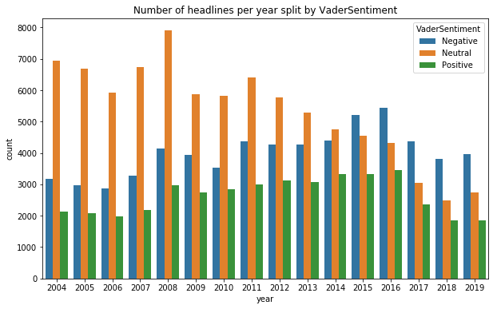

```python
plt.figure(figsize=(10,6))
sns.countplot(newsarticlesdf4['year'],hue = newsarticlesdf4['VaderSentiment'])
plt.title('Number of headlines per year split by VaderSentiment')
```

**Comments**  
Up until 2014 there were more neutral articles, however after 2015 the majority of headlines had a negative sentiment. This could be because The Guardian has a left wing stance [17]. Recent events such as Brexit and the Conservative party governing parliament.

```python
#Create a dataset from year 2015 onwards and negative sentiment
news2015 = newsarticlesdf4.loc[(newsarticlesdf4['year']>= 2015) &(newsarticlesdf4['VaderSentiment'] == 'Negative')]
news2015.shape
```

```
(22776, 26)
```

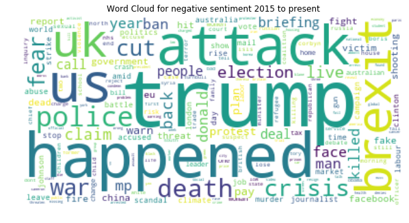

```python
#Create word cloud
text2015 = " ".join(headlines for headlines in news2015.headline_clean_stop)

wordcloud2015 = WordCloud(stopwords=stopwords, background_color="white", collocations = False).generate(text2015)

plt.figure(figsize = (10,10))
plt.imshow(wordcloud2015, interpolation='bilinear')
plt.axis("off")
plt.title('Word Cloud for negative sentiment 2015 to present')
plt.show()
```

**Comments**  
Digging deeper into the increase in negative sentiment headlines for 2015 onwards, the words associated with these headlines are 'fear' ,'attack' ,'killed','death'. There has been an increase in number of violent crimes recently [28] as well as Brexit causing uncertainty.

#### Topic Modelling and LDA

##### Q. Can news headlines be classified into topics reliably?

```python
import gensim
from gensim.utils import simple_preprocess
from gensim.parsing.preprocessing import STOPWORDS
from nltk.stem import WordNetLemmatizer, SnowballStemmer
from sklearn.feature_extraction.text import CountVectorizer
from nltk.stem.porter import *
import numpy as np
np.random.seed(2018)
import nltk
nltk.download('wordnet')
import spacy

# Gensim
import gensim
import gensim.corpora as corpora
from gensim.utils import simple_preprocess
from gensim.models import CoherenceModel

# spacy for lemmatization
import spacy

# Plotting tools
import pyLDAvis
import pyLDAvis.gensim  # don't skip this
import matplotlib.pyplot as plt
%matplotlib inline

# Enable logging for gensim - optional
import logging
logging.basicConfig(format='%(asctime)s : %(levelname)s : %(message)s', level=logging.ERROR)

import warnings
warnings.filterwarnings("ignore",category=DeprecationWarning)
import warnings
warnings.simplefilter("ignore", DeprecationWarning)
```

```python
#stem words to the root of each word e.g. publishes becomes publish. Code adapted from StackOverFlor [29]

def stem_word(text):
    tokens = text.split()
    stemmed_tokens = [PorterStemmer().stem(token) for token in tokens]
    return ' '.join(stemmed_tokens)

newsarticlesdf4['headline_clean_stop_stem'] = newsarticlesdf4['headline_clean_stop'].apply(stem_word)
newsarticlesdf4.head()
```

|  | headline | body | charCount | wordcount | lastModified | publication | webPublicationDate | PublicationDate | PublishDate | PublishTime | ... | body_clean | headline_clean_stop | body_clean_stop | polarity_headline | polarity_body | subjectivity_headline | subjectivity_body | compound | VaderSentiment | headline_clean_stop_stem |
| --- | --- | --- | --- | --- | --- | --- | --- | --- | --- | --- | --- | --- | --- | --- | --- | --- | --- | --- | --- | --- | --- |
| 0 | 8 Britons killed in South Africa road crash | Eight British tourists were killed in South Af... | 4282 | 735 | 2004-01-01T15:09:06Z | theguardian.com | 2004-01-01T15:09:06Z | 2004-01-01 15:09:06 | 2004-01-01 | 15:09:06 | ... | eight british tourists were killed in south af... | 8 britons killed south africa road crash | eight british tourists killed south africa min... | -0.2 | -0.028259 | 0.000000 | 0.287704 | -0.8020 | Negative | 8 briton kill south africa road crash |
| 1 | Beijing bursts balloon plot | An American and a New Zealander were jailed in... | 905 | 150 | 2017-07-05T13:00:54Z | theguardian.com | 2004-01-01T01:27:50Z | 2004-01-01 01:27:50 | 2004-01-01 | 01:27:50 | ... | an american and a new zealander were jailed in... | beijing bursts balloon plot | american zealander jailed beijing yesterday ch... | 0.0 | -0.087500 | 0.000000 | 0.154167 | 0.0000 | Neutral | beij burst balloon plot |
| 2 | Yangtze water plan extended | China has started building a new section of a ... | 890 | 150 | 2004-01-01T01:27:51Z | theguardian.com | 2004-01-01T01:27:51Z | 2004-01-01 01:27:51 | 2004-01-01 | 01:27:51 | ... | china has started building a new section of a ... | yangtze water plan extended | china started building section multibillionpou... | 0.0 | 0.109259 | 0.000000 | 0.481481 | 0.0000 | Neutral | yangtz water plan extend |
| 3 | UK feared Americans would invade Gulf during 1... | Ted Heath's government feared - at the height ... | 4350 | 705 | 2017-07-15T03:37:57Z | theguardian.com | 2004-01-01T01:28:20Z | 2004-01-01 01:28:20 | 2004-01-01 | 01:28:20 | ... | ted heaths government feared at the height of... | uk feared americans invade gulf 1973 oil crisis | ted heaths government feared height 1973 oil c... | 0.0 | 0.035663 | 0.000000 | 0.343582 | -0.8074 | Negative | uk fear american invad gulf 1973 oil crisi |
| 4 | In brief | Baby loses fight for life Callum Taylor, an ... | 1555 | 268 | 2004-01-01T01:28:23Z | theguardian.com | 2004-01-01T01:28:23Z | 2004-01-01 01:28:23 | 2004-01-01 | 01:28:23 | ... | baby loses fight for life callum taylor an eig... | brief | baby loses fight life callum taylor eightmonth... | 0.0 | 0.021795 | 0.333333 | 0.242308 | 0.0000 | Neutral | brief |

5 rows × 27 columns

```python
#Column headline_clean_stop excludes stopwords and punctuation
#Create list of headline clean text

headline_text = newsarticlesdf4.headline_clean_stop_stem.values.tolist()
print(headline_text[:1])
```

```
['8 briton kill south africa road crash']
```

```python
#Code for LDA modelling has been adapted from DataSkunkWorks [30] and Machine Learning Plus [32]
#Tokenize words which is required by LDA
def doc_words(sentences):
    for sentence in sentences:
        yield(gensim.utils.simple_preprocess(str(sentence),deacc = True))

headlinewords = list(doc_words(headline_text))

print(headlinewords[:1])
```

```
[['briton', 'kill', 'south', 'africa', 'road', 'crash']]
```

```python
import gensim.corpora as corpora
id2word = corpora.Dictionary(headlinewords)

# Create Corpus
corpus = [id2word.doc2bow(text) for text in headlinewords]

# Build LDA model
lda_model = gensim.models.ldamodel.LdaModel(corpus=corpus,
                                           id2word=id2word,
                                           num_topics=4,
                                           per_word_topics=True)
```

```python
# Compute Perplexity score
print('\nPerplexity: ', lda_model.log_perplexity(corpus))

# Compute Coherence Score
coherence_model_lda = CoherenceModel(model=lda_model, texts=headlinewords, dictionary=id2word, coherence='c_v')
coherence_lda = coherence_model_lda.get_coherence()
print('\nCoherence Score: ', coherence_lda)
```

```
Perplexity:  -8.853080856989303

Coherence Score:  0.1775079974217622
```

```python
from pprint import pprint
pprint(lda_model.print_topics())
doc_lda = lda_model[corpus]
```

```
[(0,
  '0.040*"happen" + 0.033*"brexit" + 0.016*"brief" + 0.014*"johnson" + '
  '0.013*"uk" + 0.011*"us" + 0.010*"bori" + 0.008*"donald" + 0.007*"hous" + '
  '0.007*"world"'),
 (1,
  '0.009*"say" + 0.009*"facebook" + 0.008*"chang" + 0.007*"climat" + '
  '0.007*"plan" + 0.007*"live" + 0.007*"mail" + 0.007*"bbc" + 0.006*"cut" + '
  '0.006*"morn"'),
 (2,
  '0.047*"trump" + 0.015*"say" + 0.011*"attack" + 0.010*"polic" + '
  '0.010*"polit" + 0.006*"kill" + 0.006*"protest" + 0.006*"accus" + 0.006*"eu" '
  '+ 0.006*"crisi"'),
 (3,
  '0.011*"tori" + 0.010*"elect" + 0.009*"govern" + 0.009*"death" + '
  '0.009*"australia" + 0.009*"peopl" + 0.008*"year" + 0.008*"day" + 0.007*"us" '
  '+ 0.007*"labor"')]
```

```python
pyLDAvis.enable_notebook()
vis = pyLDAvis.gensim.prepare(lda_model, corpus, id2word)
vis
```

[interactive chart not shown]

**Comments**

```python
# Find the optimal number of topics for LDA using gensim
def compute_coherence_values(dictionary, corpus, texts, limit, start=2, step=3):
    """
    Compute c_v coherence for various number of topics

    Parameters:
    ----------
    dictionary : Gensim dictionary
    corpus : Gensim corpus
    texts : List of input texts
    limit : Max num of topics

    Returns:
    -------
    model_list : List of LDA topic models
    coherence_values : Coherence values corresponding to the LDA model with respective number of topics
    """
    coherence_values = []
    model_list = []
    for num_topics in range(start, limit, step):
        model = gensim.models.ldamodel.LdaModel(corpus=corpus, num_topics=num_topics, id2word=id2word,per_word_topics=True)
        model_list.append(model)
        coherencemodel = CoherenceModel(model=model, texts=texts, dictionary=dictionary, coherence='c_v')
        coherence_values.append(coherencemodel.get_coherence())

    return model_list, coherence_values
```

```python
#Find optimal number of topics - TAKES LONG TO RUN
model_list, coherence_values = compute_coherence_values(dictionary=id2word, corpus=corpus, texts=headlinewords, start=2, limit=60, step=6)
```

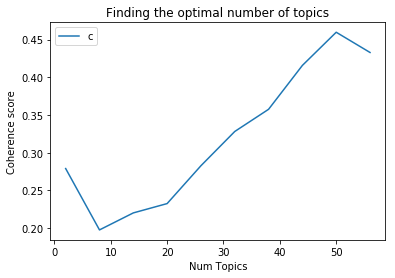

```python
#Show graph
limit=60; start=2; step=6;
x = range(start, limit, step)
plt.plot(x, coherence_values)
plt.xlabel("Num Topics")
plt.ylabel("Coherence score")
plt.legend(("coherence_values"), loc='best')
plt.title('Finding the optimal number of topics')
plt.show()
```

```python
# Print the coherence scores
for y, cv in zip(x, coherence_values):
    print("Num Topics =", y, " has Coherence Value of", round(cv, 4))
```

```
Num Topics = 2  has Coherence Value of 0.2789
Num Topics = 8  has Coherence Value of 0.1975
Num Topics = 14  has Coherence Value of 0.22
Num Topics = 20  has Coherence Value of 0.2324
Num Topics = 26  has Coherence Value of 0.2827
Num Topics = 32  has Coherence Value of 0.3281
Num Topics = 38  has Coherence Value of 0.3576
Num Topics = 44  has Coherence Value of 0.4158
Num Topics = 50  has Coherence Value of 0.4598
Num Topics = 56  has Coherence Value of 0.433
```

**Comments**  
Coherence allows us to judge how good the topic model is. From the graph above, the coherence score is at its highest at 50 topics. We will change the LDA topic number to 50 below and visualize them.

```python
id2word = corpora.Dictionary(headlinewords)

#Create Corpus
corpus = [id2word.doc2bow(text) for text in headlinewords]

#Build LDA model
lda_model_optimise = gensim.models.ldamodel.LdaModel(corpus=corpus,
                                          id2word=id2word,
                                          num_topics=50,
                                          per_word_topics=True)
```

```python
from pprint import pprint
pprint(lda_model_optimise.print_topics())
doc_lda_optimise = lda_model_optimise[corpus]
```

```
[(43,
  '0.208*"kill" + 0.088*"abus" + 0.078*"suspect" + 0.076*"car" + 0.070*"left" '
  '+ 0.063*"bomb" + 0.038*"run" + 0.036*"near" + 0.031*"moment" + '
  '0.030*"littl"'),
 (26,
  '0.138*"war" + 0.117*"job" + 0.096*"meet" + 0.064*"close" + 0.062*"save" + '
  '0.061*"threaten" + 0.059*"street" + 0.058*"resign" + 0.053*"race" + '
  '0.043*"wall"'),
 (38,
  '0.201*"fear" + 0.157*"russia" + 0.117*"power" + 0.085*"health" + '
  '0.074*"terror" + 0.053*"pledg" + 0.043*"cultur" + 0.033*"beat" + '
  '0.029*"strategi" + 0.019*"ofcom"'),
 (20,
  '0.197*"eu" + 0.118*"ban" + 0.102*"amid" + 0.091*"case" + 0.072*"target" + '
  '0.046*"tri" + 0.043*"behind" + 0.039*"manchest" + 0.038*"travel" + '
  '0.035*"letter"'),
 (1,
  '0.183*"man" + 0.170*"journalist" + 0.116*"dont" + 0.111*"student" + '
  '0.070*"un" + 0.056*"spi" + 0.047*"trust" + 0.036*"breach" + 0.024*"short" + '
  '0.023*"inform"'),
 (31,
  '0.198*"time" + 0.125*"shoot" + 0.117*"citi" + 0.096*"bid" + 0.046*"hour" + '
  '0.036*"held" + 0.035*"advis" + 0.032*"sell" + 0.030*"benefit" + '
  '0.029*"takeov"'),
 (34,
  '0.342*"live" + 0.052*"european" + 0.050*"million" + 0.048*"biggest" + '
  '0.048*"pass" + 0.047*"post" + 0.045*"editor" + 0.038*"tackl" + '
  '0.035*"increas" + 0.032*"scientist"'),
 (42,
  '0.178*"death" + 0.086*"find" + 0.067*"offici" + 0.062*"drop" + '
  '0.062*"activist" + 0.047*"month" + 0.043*"princ" + 0.038*"appl" + '
  '0.035*"worst" + 0.033*"father"'),
 (8,
  '0.131*"fire" + 0.117*"market" + 0.110*"nation" + 0.105*"help" + '
  '0.070*"defend" + 0.056*"ask" + 0.054*"open" + 0.052*"andrew" + '
  '0.043*"legal" + 0.024*"phone"'),
 (0,
  '0.147*"mail" + 0.122*"inquiri" + 0.107*"minist" + 0.104*"end" + '
  '0.094*"support" + 0.072*"turn" + 0.062*"strike" + 0.050*"demand" + '
  '0.038*"admit" + 0.036*"independ"'),
```

[output cut: 24 more lines]

```
 (15,
  '0.419*"happen" + 0.055*"trade" + 0.054*"north" + 0.045*"law" + '
  '0.042*"korea" + 0.038*"south" + 0.028*"name" + 0.028*"googl" + 0.026*"mark" '
  '+ 0.025*"link"'),
 (10,
  '0.132*"crisi" + 0.118*"talk" + 0.112*"one" + 0.075*"poll" + 0.067*"dead" + '
  '0.052*"block" + 0.051*"remain" + 0.046*"doctor" + 0.039*"violenc" + '
  '0.032*"publish"'),
 (45,
  '0.192*"peopl" + 0.104*"british" + 0.080*"releas" + 0.072*"found" + '
  '0.067*"visit" + 0.066*"candid" + 0.057*"prison" + 0.056*"trial" + '
  '0.045*"japan" + 0.038*"journal"'),
 (11,
  '0.095*"key" + 0.089*"futur" + 0.077*"wont" + 0.075*"miss" + 0.063*"stock" + '
  '0.062*"hunt" + 0.061*"im" + 0.055*"feel" + 0.050*"putin" + 0.049*"cancer"')]
```

```python
pyLDAvis.enable_notebook()
vis = pyLDAvis.gensim.prepare(lda_model_optimise, corpus, id2word)
vis
```

[interactive chart not shown]

**Comments**  
50 topics shows the highest coherent score which shows the model is optimal. However, when applying 50 topics nearly all topics overlap. Looking at the four topics generated we can't easily give them a label, hence we can't generate topics reliably. Classifying topics for different years may yield better results.

```python
model_list = lda_model.print_topics()
model_list
```

```
[(0,
  '0.040*"happen" + 0.033*"brexit" + 0.016*"brief" + 0.014*"johnson" + 0.013*"uk" + 0.011*"us" + 0.010*"bori" + 0.008*"donald" + 0.007*"hous" + 0.007*"world"'),
 (1,
  '0.009*"say" + 0.009*"facebook" + 0.008*"chang" + 0.007*"climat" + 0.007*"plan" + 0.007*"live" + 0.007*"mail" + 0.007*"bbc" + 0.006*"cut" + 0.006*"morn"'),
 (2,
  '0.047*"trump" + 0.015*"say" + 0.011*"attack" + 0.010*"polic" + 0.010*"polit" + 0.006*"kill" + 0.006*"protest" + 0.006*"accus" + 0.006*"eu" + 0.006*"crisi"'),
 (3,
  '0.011*"tori" + 0.010*"elect" + 0.009*"govern" + 0.009*"death" + 0.009*"australia" + 0.009*"peopl" + 0.008*"year" + 0.008*"day" + 0.007*"us" + 0.007*"labor"')]
```

```python
lda_model.show_topic(1)
```

```
[('say', 0.009467011),
 ('facebook', 0.008803813),
 ('chang', 0.0075215474),
 ('climat', 0.0072623217),
 ('plan', 0.0071709338),
 ('live', 0.006940481),
 ('mail', 0.0068774647),
 ('bbc', 0.00662942),
 ('cut', 0.006343276),
 ('morn', 0.006050334)]
```

```python
lda_model[corpus]
```

```
<gensim.interfaces.TransformedCorpus at 0x18083b2b080>
```

```python
lda_model[corpus[1]]
```

```
([(0, 0.24614702), (1, 0.05004319), (2, 0.653766), (3, 0.050043803)],
 [(6, [2]), (7, [2]), (8, [2]), (9, [0, 2])],
 [(6, [(2, 0.9975447)]),
  (7, [(2, 0.9995324)]),
  (8, [(2, 0.9991254)]),
  (9, [(0, 0.9793983), (2, 0.019902315)])])
```

```python
test_topics = lda_model.get_document_topics(corpus[0])
test_topics
```

```
[(0, 0.5574413), (1, 0.03571996), (2, 0.37111878), (3, 0.035719983)]
```

```python
test_topics_max = max(test_topics, key=lambda x: x[1])
test_topics_max
```

```
(0, 0.5574413)
```

```python
test_topics2 = pd.DataFrame(list(test_topics_max))
```

```python
test_topics2 = test_topics2.transpose()
```

```python
test_topics2.columns=['Topic','Percentage']
test_topics2
```

|  | Topic | Percentage |
| --- | --- | --- |
| 0 | 0.0 | 0.557441 |

```python
#Get the topics and their percentage contribution for the headline
get_document_topics = [lda_model.get_document_topics(item) for item in corpus]
```

```python
document_topics_df = pd.DataFrame(list(get_document_topics))
document_topics_df.head()
```

|  | 0 | 1 | 2 | 3 |
| --- | --- | --- | --- | --- |
| 0 | (0, 0.5574369) | (1, 0.035719965) | (2, 0.3711232) | (3, 0.035719983) |
| 1 | (0, 0.24614742) | (1, 0.050043188) | (2, 0.6537656) | (3, 0.050043795) |
| 2 | (0, 0.2313359) | (1, 0.66761154) | (2, 0.050787576) | (3, 0.05026499) |
| 3 | (0, 0.22146955) | (1, 0.2536545) | (2, 0.25446445) | (3, 0.2704115) |
| 4 | (0, 0.62499714) | (1, 0.12500095) | (2, 0.12500095) | (3, 0.12500097) |

```python
document_topics_df.shape
```

```
(191648, 4)
```

```python
#Find the maximum percentage contribution for the row to identify the dominant topic
test_max = [max(p,key=lambda x: x[1]) for p in get_document_topics]
test_max
```

```
[(0, 0.5574369),
 (2, 0.6537656),
 (1, 0.66761154),
 (3, 0.2704115),
 (0, 0.62499714),
 (0, 0.6249971),
 (2, 0.44854376),
 (3, 0.44983384),
 (1, 0.5669273),
 (1, 0.5510661),
 (2, 0.87498474),
 (3, 0.41665646),
 (3, 0.8544767),
 (0, 0.8081507),
 (3, 0.5417109),
 (0, 0.45626011),
 (1, 0.48725393),
 (2, 0.54208815),
 (2, 0.70100725),
 (1, 0.69866174),
 (0, 0.62499714),
 (2, 0.7497479),
 (0, 0.8729157),
 (1, 0.5324605),
 (0, 0.5862653),
 (0, 0.62499714),
 (0, 0.6249971),
 (1, 0.49232116),
 (3, 0.594262),
 (0, 0.5041099),
 (2, 0.5417078),
 (1, 0.47111538),
 (3, 0.56252575),
 (0, 0.7496011),
 (3, 0.84179866),
 (0, 0.62499714),
 (1, 0.7284933),
 (0, 0.87108177),
 (2, 0.4789238),
 (0, 0.7368166),
```

[output cut: 946 more lines]

```
 (0, 0.62481064),
 (3, 0.7498738),
 (1, 0.8747598),
 (1, 0.4542988),
 (2, 0.7897373),
 (1, 0.6214705),
 (2, 0.45898226),
 (3, 0.7496523),
 (0, 0.7470893),
 (0, 0.5642478),
 (3, 0.45325693),
 (0, 0.7340096),
 (0, 0.62499714),
 (3, 0.420495),
 ...]
```

```python
#Apply the above to a dataframe and rename the columns to topic and percentage contribution
doc_topics = pd.DataFrame(test_max)
doc_topics.columns = ['Topic','Percentage_Contribution']
doc_topics
```

|  | Topic | Percentage_Contribution |
| --- | --- | --- |
| 0 | 0 | 0.557437 |
| 1 | 2 | 0.653766 |
| 2 | 1 | 0.667612 |
| 3 | 3 | 0.270411 |
| 4 | 0 | 0.624997 |
| ... | ... | ... |
| 191643 | 1 | 0.530794 |
| 191644 | 0 | 0.391685 |
| 191645 | 0 | 0.537157 |
| 191646 | 1 | 0.346314 |
| 191647 | 0 | 0.553116 |

191648 rows × 2 columns

```python
#Join back to original df newsarticlesdf4

newsarticlesdf5 = newsarticlesdf4.merge(doc_topics,left_index = True, right_index = True)
newsarticlesdf5.head()
```

|  | headline | body | charCount | wordcount | lastModified | publication | webPublicationDate | PublicationDate | PublishDate | PublishTime | ... | body_clean_stop | polarity_headline | polarity_body | subjectivity_headline | subjectivity_body | compound | VaderSentiment | headline_clean_stop_stem | Topic | Percentage_Contribution |
| --- | --- | --- | --- | --- | --- | --- | --- | --- | --- | --- | --- | --- | --- | --- | --- | --- | --- | --- | --- | --- | --- |
| 0 | 8 Britons killed in South Africa road crash | Eight British tourists were killed in South Af... | 4282 | 735 | 2004-01-01T15:09:06Z | theguardian.com | 2004-01-01T15:09:06Z | 2004-01-01 15:09:06 | 2004-01-01 | 15:09:06 | ... | eight british tourists killed south africa min... | -0.2 | -0.028259 | 0.000000 | 0.287704 | -0.8020 | Negative | 8 briton kill south africa road crash | 0 | 0.557437 |
| 1 | Beijing bursts balloon plot | An American and a New Zealander were jailed in... | 905 | 150 | 2017-07-05T13:00:54Z | theguardian.com | 2004-01-01T01:27:50Z | 2004-01-01 01:27:50 | 2004-01-01 | 01:27:50 | ... | american zealander jailed beijing yesterday ch... | 0.0 | -0.087500 | 0.000000 | 0.154167 | 0.0000 | Neutral | beij burst balloon plot | 2 | 0.653766 |
| 2 | Yangtze water plan extended | China has started building a new section of a ... | 890 | 150 | 2004-01-01T01:27:51Z | theguardian.com | 2004-01-01T01:27:51Z | 2004-01-01 01:27:51 | 2004-01-01 | 01:27:51 | ... | china started building section multibillionpou... | 0.0 | 0.109259 | 0.000000 | 0.481481 | 0.0000 | Neutral | yangtz water plan extend | 1 | 0.667612 |
| 3 | UK feared Americans would invade Gulf during 1... | Ted Heath's government feared - at the height ... | 4350 | 705 | 2017-07-15T03:37:57Z | theguardian.com | 2004-01-01T01:28:20Z | 2004-01-01 01:28:20 | 2004-01-01 | 01:28:20 | ... | ted heaths government feared height 1973 oil c... | 0.0 | 0.035663 | 0.000000 | 0.343582 | -0.8074 | Negative | uk fear american invad gulf 1973 oil crisi | 3 | 0.270411 |
| 4 | In brief | Baby loses fight for life Callum Taylor, an ... | 1555 | 268 | 2004-01-01T01:28:23Z | theguardian.com | 2004-01-01T01:28:23Z | 2004-01-01 01:28:23 | 2004-01-01 | 01:28:23 | ... | baby loses fight life callum taylor eightmonth... | 0.0 | 0.021795 | 0.333333 | 0.242308 | 0.0000 | Neutral | brief | 0 | 0.624997 |

5 rows × 29 columns

```python
#Output the words associated with each topic
x = lda_model.show_topics()

nwords = {}
for topic,word in x:
    nwords[topic] = re.sub('[^A-Za-z ]+','',word)

nwords
```

```
{0: 'happen  brexit  brief  johnson  uk  us  bori  donald  hous  world',
 1: 'say  facebook  chang  climat  plan  live  mail  bbc  cut  morn',
 2: 'trump  say  attack  polic  polit  kill  protest  accus  eu  crisi',
 3: 'tori  elect  govern  death  australia  peopl  year  day  us  labor'}
```

```python
#Apply above to a df to join to newsarticlesdf5
topic_words = pd.DataFrame(list(nwords.items()),columns=['Topic', 'Topic_Words'])
topic_words
```

|  | Topic | Topic_Words |
| --- | --- | --- |
| 0 | 0 | happen brexit brief johnson uk us bori ... |
| 1 | 1 | say facebook chang climat plan live mail... |
| 2 | 2 | trump say attack polic polit kill protes... |
| 3 | 3 | tori elect govern death australia peopl ... |

```python
#Join to newsarticlesdf5 to get topic words and sort by PublishDate

newsarticlesdf6 = pd.merge(newsarticlesdf5,topic_words,left_on = 'Topic', right_on = 'Topic')
newsarticlesdf6.sort_values(by=['PublishDate'], inplace=True)
newsarticlesdf6.reset_index(drop = True, inplace = True)
newsarticlesdf6.head()
```

|  | headline | body | charCount | wordcount | lastModified | publication | webPublicationDate | PublicationDate | PublishDate | PublishTime | ... | polarity_headline | polarity_body | subjectivity_headline | subjectivity_body | compound | VaderSentiment | headline_clean_stop_stem | Topic | Percentage_Contribution | Topic_Words |
| --- | --- | --- | --- | --- | --- | --- | --- | --- | --- | --- | --- | --- | --- | --- | --- | --- | --- | --- | --- | --- | --- |
| 0 | 8 Britons killed in South Africa road crash | Eight British tourists were killed in South Af... | 4282 | 735 | 2004-01-01T15:09:06Z | theguardian.com | 2004-01-01T15:09:06Z | 2004-01-01 15:09:06 | 2004-01-01 | 15:09:06 | ... | -0.2 | -0.028259 | 0.0 | 0.287704 | -0.8020 | Negative | 8 briton kill south africa road crash | 0 | 0.557437 | happen brexit brief johnson uk us bori ... |
| 1 | Israeli soldier held on shooting of Briton | The following correction was printed in the Gu... | 4581 | 769 | 2017-05-08T07:32:28Z | theguardian.com | 2004-01-01T13:56:10Z | 2004-01-01 13:56:10 | 2004-01-01 | 13:56:10 | ... | 0.0 | 0.049019 | 0.0 | 0.312132 | 0.0000 | Neutral | isra soldier held shoot briton | 2 | 0.874985 | trump say attack polic polit kill protes... |
| 2 | Yangtze water plan extended | China has started building a new section of a ... | 890 | 150 | 2004-01-01T01:27:51Z | theguardian.com | 2004-01-01T01:27:51Z | 2004-01-01 01:27:51 | 2004-01-01 | 01:27:51 | ... | 0.0 | 0.109259 | 0.0 | 0.481481 | 0.0000 | Neutral | yangtz water plan extend | 1 | 0.667612 | say facebook chang climat plan live mail... |
| 3 | Heath feared US plan to invade Gulf | Ted Heath's government feared - at the height ... | 2270 | 364 | 2017-07-15T03:37:56Z | theguardian.com | 2004-01-01T10:27:36Z | 2004-01-01 10:27:36 | 2004-01-01 | 10:27:36 | ... | 0.0 | 0.042177 | 0.0 | 0.428912 | -0.4939 | Negative | heath fear us plan invad gulf | 1 | 0.566927 | say facebook chang climat plan live mail... |
| 4 | Aitken's Middle East foray sparked row | Jonathan Aitken so infuriated the Foreign Offi... | 2778 | 447 | 2017-05-08T07:32:29Z | theguardian.com | 2004-01-01T10:29:03Z | 2004-01-01 10:29:03 | 2004-01-01 | 10:29:03 | ... | 0.0 | 0.016536 | 0.0 | 0.182612 | 0.0000 | Neutral | aitken middl east foray spark row | 1 | 0.551066 | say facebook chang climat plan live mail... |

5 rows × 30 columns

```python
newsarticlesdf6.shape
```

```
(190231, 30)
```

```python
#Run Vader on topic words

topic_sentiment = newsarticlesdf6['Topic_Words'].apply(lambda x: analyzer.polarity_scores(x))
newsarticlesdf7 = pd.concat([newsarticlesdf6,topic_sentiment.apply(pd.Series)],1)
newsarticlesdf7.head()
```

|  | headline | body | charCount | wordcount | lastModified | publication | webPublicationDate | PublicationDate | PublishDate | PublishTime | ... | compound | VaderSentiment | headline_clean_stop_stem | Topic | Percentage_Contribution | Topic_Words | neg | neu | pos | compound |
| --- | --- | --- | --- | --- | --- | --- | --- | --- | --- | --- | --- | --- | --- | --- | --- | --- | --- | --- | --- | --- | --- |
| 0 | 8 Britons killed in South Africa road crash | Eight British tourists were killed in South Af... | 4282 | 735 | 2004-01-01T15:09:06Z | theguardian.com | 2004-01-01T15:09:06Z | 2004-01-01 15:09:06 | 2004-01-01 | 15:09:06 | ... | -0.8020 | Negative | 8 briton kill south africa road crash | 0 | 0.557437 | happen brexit brief johnson uk us bori ... | 0.000 | 1.000 | 0.0 | 0.0000 |
| 1 | Israeli soldier held on shooting of Briton | The following correction was printed in the Gu... | 4581 | 769 | 2017-05-08T07:32:28Z | theguardian.com | 2004-01-01T13:56:10Z | 2004-01-01 13:56:10 | 2004-01-01 | 13:56:10 | ... | 0.0000 | Neutral | isra soldier held shoot briton | 2 | 0.874985 | trump say attack polic polit kill protes... | 0.583 | 0.417 | 0.0 | -0.8689 |
| 2 | Yangtze water plan extended | China has started building a new section of a ... | 890 | 150 | 2004-01-01T01:27:51Z | theguardian.com | 2004-01-01T01:27:51Z | 2004-01-01 01:27:51 | 2004-01-01 | 01:27:51 | ... | 0.0000 | Neutral | yangtz water plan extend | 1 | 0.667612 | say facebook chang climat plan live mail... | 0.189 | 0.811 | 0.0 | -0.2732 |
| 3 | Heath feared US plan to invade Gulf | Ted Heath's government feared - at the height ... | 2270 | 364 | 2017-07-15T03:37:56Z | theguardian.com | 2004-01-01T10:27:36Z | 2004-01-01 10:27:36 | 2004-01-01 | 10:27:36 | ... | -0.4939 | Negative | heath fear us plan invad gulf | 1 | 0.566927 | say facebook chang climat plan live mail... | 0.189 | 0.811 | 0.0 | -0.2732 |
| 4 | Aitken's Middle East foray sparked row | Jonathan Aitken so infuriated the Foreign Offi... | 2778 | 447 | 2017-05-08T07:32:29Z | theguardian.com | 2004-01-01T10:29:03Z | 2004-01-01 10:29:03 | 2004-01-01 | 10:29:03 | ... | 0.0000 | Neutral | aitken middl east foray spark row | 1 | 0.551066 | say facebook chang climat plan live mail... | 0.189 | 0.811 | 0.0 | -0.2732 |

5 rows × 34 columns

```python
newsarticlesdf7.info()
```

```
<class 'pandas.core.frame.DataFrame'>
RangeIndex: 190231 entries, 0 to 190230
Data columns (total 34 columns):
headline                    190231 non-null object
body                        190231 non-null object
charCount                   190231 non-null object
wordcount                   190231 non-null object
lastModified                190231 non-null object
publication                 190231 non-null object
webPublicationDate          190231 non-null object
PublicationDate             190231 non-null datetime64[ns]
PublishDate                 190231 non-null datetime64[ns]
PublishTime                 190231 non-null object
day_of_week                 190231 non-null object
month                       190231 non-null int64
Month full                  190231 non-null object
year                        190231 non-null int64
headline_text_count         190231 non-null int64
headline_char_count         190231 non-null int64
headline_clean              190231 non-null object
body_clean                  190231 non-null object
headline_clean_stop         190231 non-null object
body_clean_stop             190231 non-null object
polarity_headline           190231 non-null float64
polarity_body               190231 non-null float64
subjectivity_headline       190231 non-null float64
subjectivity_body           190231 non-null float64
compound                    190231 non-null float64
VaderSentiment              190231 non-null object
headline_clean_stop_stem    190231 non-null object
Topic                       190231 non-null int64
Percentage_Contribution     190231 non-null float64
Topic_Words                 190231 non-null object
neg                         190231 non-null float64
neu                         190231 non-null float64
pos                         190231 non-null float64
compound                    190231 non-null float64
dtypes: datetime64[ns](2), float64(10), int64(5), object(17)
memory usage: 49.3+ MB
```

```python
newsarticlesdf8 = newsarticlesdf7[['PublishDate','compound']]
newsarticlesdf8.columns = ['PublishDate','HeadlineCompound','TopicCompound']
newsarticlesdf8.reset_index()
newsarticlesdf8.head(20)
```

|  | PublishDate | HeadlineCompound | TopicCompound |
| --- | --- | --- | --- |
| 0 | 2004-01-01 | -0.8020 | 0.0000 |
| 1 | 2004-01-01 | 0.0000 | -0.8689 |
| 2 | 2004-01-01 | 0.0000 | -0.2732 |
| 3 | 2004-01-01 | -0.4939 | -0.2732 |
| 4 | 2004-01-01 | 0.0000 | -0.2732 |
| 5 | 2004-01-01 | -0.8718 | -0.8689 |
| 6 | 2004-01-01 | -0.8074 | -0.5994 |
| 7 | 2004-01-01 | 0.5106 | -0.5994 |
| 8 | 2004-01-01 | 0.2023 | -0.5994 |
| 9 | 2004-01-01 | 0.0000 | -0.8689 |
| 10 | 2004-01-01 | 0.0000 | 0.0000 |
| 11 | 2004-01-01 | 0.0000 | 0.0000 |
| 12 | 2004-01-02 | -0.3400 | -0.8689 |
| 13 | 2004-01-02 | 0.0000 | 0.0000 |
| 14 | 2004-01-02 | 0.0000 | -0.2732 |
| 15 | 2004-01-02 | 0.0000 | -0.2732 |
| 16 | 2004-01-02 | 0.0000 | -0.2732 |
| 17 | 2004-01-02 | -0.7430 | -0.8689 |
| 18 | 2004-01-02 | 0.0000 | -0.8689 |
| 19 | 2004-01-02 | 0.2023 | 0.0000 |

```python
newsarticlesdf9 = newsarticlesdf8.groupby('PublishDate').mean()
newsarticlesdf9.head()
```

| PublishDate | HeadlineCompound | TopicCompound |
| --- | --- | --- |
| 2004-01-01 | -0.188517 | -0.435375 |
| 2004-01-02 | -0.115915 | -0.355777 |
| 2004-01-03 | -0.045793 | -0.290373 |
| 2004-01-04 | 0.037876 | -0.458543 |
| 2004-01-05 | 0.027370 | -0.348022 |

### Stock market data

Features to be added to the stock market data

- Change exchange rate of S&P 500 index from USD to GBP
- EWMA - Exponential Weighted Moving Average
- Trading Strategy

```python
#Join the ASX200 dataset and FXAud dataset in order to apply conversion to the S&P/ASX200 price to USD.

SP500Conversion  = pd.merge(SP500Time,FXUSDTime, on = 'Date')
SP500Conversion.columns = ['SP500_Close_USD','USD_Price','Change %']
SP500Conversion['SP500_Close_GBP'] = SP500Conversion['SP500_Close_USD'] * SP500Conversion['USD_Price']
SP500Conversion.drop(labels = ['Change %'], axis = 'columns', inplace = True)
SP500Conversion.head()
```

| Date | SP500_Close_USD | USD_Price | SP500_Close_GBP |
| --- | --- | --- | --- |
| 2004-01-02 | 1108.479980 | 0.5576 | 618.088437 |
| 2004-01-03 | 1108.479980 | 0.5576 | 618.088437 |
| 2004-01-04 | 1108.479980 | 0.5576 | 618.088437 |
| 2004-01-05 | 1122.219971 | 0.5535 | 621.148754 |
| 2004-01-06 | 1123.670044 | 0.5490 | 616.894854 |

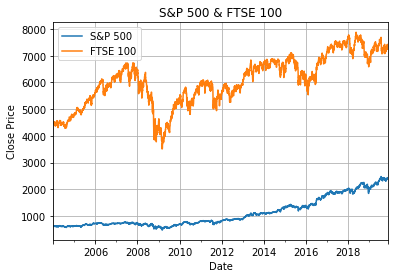

```python
SP500Conversion['SP500_Close_GBP'].plot(grid = True, label = "S&P 500")
ftseTime['Close'].plot(grid = True , label = "FTSE 100")

plt.ylabel('Close Price')
plt.title('S&P 500 & FTSE 100')
plt.legend()
plt.show()
```

```python
#Exponential Weighted Moving Average using 253 days, indicating an exponentially weight moving average over a year.
#The average number of trading days per calendar year is 253 days [33]
ftseTime['EWMA'] = ftseTime['Close'].ewm(span=253).mean()
ftseTime.head()
```

| Date | Close | EWMA |
| --- | --- | --- |
| 2004-01-02 | 4510.2 | 4510.200000 |
| 2004-01-03 | 4510.2 | 4510.200000 |
| 2004-01-04 | 4510.2 | 4510.200000 |
| 2004-01-05 | 4513.3 | 4510.984214 |
| 2004-01-06 | 4505.2 | 4509.809009 |

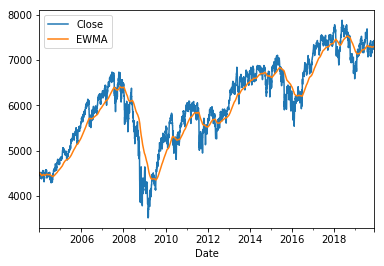

```python
ftseTime[['Close','EWMA']].plot()
```

EWMA Strategy

- When the price crosses the EWMA curve from above - short (sell) the index - close price < EWMA
- When the price crosses the EWMA curve from below - long (buy) the index - close price > EWMA

```python
ftseTime['Difference'] = ftseTime['Close'] - ftseTime['EWMA']
ftseTime.head()
```

| Date | Close | EWMA | Difference |
| --- | --- | --- | --- |
| 2004-01-02 | 4510.2 | 4510.200000 | 0.000000 |
| 2004-01-03 | 4510.2 | 4510.200000 | 0.000000 |
| 2004-01-04 | 4510.2 | 4510.200000 | 0.000000 |
| 2004-01-05 | 4513.3 | 4510.984214 | 2.315786 |
| 2004-01-06 | 4505.2 | 4509.809009 | -4.609009 |

```python
def trading_strat(num):
    if num > 0:
        return "Long"
    elif num <0:
        return "Short"
    else:
        return "Hold"

ftseTime['Trading_Strategy'] = ftseTime['Difference'].apply(trading_strat)
ftseTime.head()
```

| Date | Close | EWMA | Difference | Trading_Strategy |
| --- | --- | --- | --- | --- |
| 2004-01-02 | 4510.2 | 4510.200000 | 0.000000 | Hold |
| 2004-01-03 | 4510.2 | 4510.200000 | 0.000000 | Hold |
| 2004-01-04 | 4510.2 | 4510.200000 | 0.000000 | Hold |
| 2004-01-05 | 4513.3 | 4510.984214 | 2.315786 | Long |
| 2004-01-06 | 4505.2 | 4509.809009 | -4.609009 | Short |

```python
#Create new index for ftseTime df
ftseTime1 = ftseTime.reset_index()
ftseTime1.head()
```

|  | Date | Close | EWMA | Difference | Trading_Strategy |
| --- | --- | --- | --- | --- | --- |
| 0 | 2004-01-02 | 4510.2 | 4510.200000 | 0.000000 | Hold |
| 1 | 2004-01-03 | 4510.2 | 4510.200000 | 0.000000 | Hold |
| 2 | 2004-01-04 | 4510.2 | 4510.200000 | 0.000000 | Hold |
| 3 | 2004-01-05 | 4513.3 | 4510.984214 | 2.315786 | Long |
| 4 | 2004-01-06 | 4505.2 | 4509.809009 | -4.609009 | Short |

```python
#Create new index for newsarticlesdf9 which contains sentiment analysis on headline and topic
newsarticlesdf10 = newsarticlesdf9.reset_index()
newsarticlesdf10.head()
```

|  | PublishDate | HeadlineCompound | TopicCompound |
| --- | --- | --- | --- |
| 0 | 2004-01-01 | -0.188517 | -0.435375 |
| 1 | 2004-01-02 | -0.115915 | -0.355777 |
| 2 | 2004-01-03 | -0.045793 | -0.290373 |
| 3 | 2004-01-04 | 0.037876 | -0.458543 |
| 4 | 2004-01-05 | 0.027370 | -0.348022 |

```python
ftseSentiment = pd.merge(ftseTime1,newsarticlesdf10,left_on = "Date", right_on = "PublishDate", how = "left")
ftseSentiment.head()
```

|  | Date | Close | EWMA | Difference | Trading_Strategy | PublishDate | HeadlineCompound | TopicCompound |
| --- | --- | --- | --- | --- | --- | --- | --- | --- |
| 0 | 2004-01-02 | 4510.2 | 4510.200000 | 0.000000 | Hold | 2004-01-02 | -0.115915 | -0.355777 |
| 1 | 2004-01-03 | 4510.2 | 4510.200000 | 0.000000 | Hold | 2004-01-03 | -0.045793 | -0.290373 |
| 2 | 2004-01-04 | 4510.2 | 4510.200000 | 0.000000 | Hold | 2004-01-04 | 0.037876 | -0.458543 |
| 3 | 2004-01-05 | 4513.3 | 4510.984214 | 2.315786 | Long | 2004-01-05 | 0.027370 | -0.348022 |
| 4 | 2004-01-06 | 4505.2 | 4509.809009 | -4.609009 | Short | 2004-01-06 | -0.032039 | -0.378247 |

**Comments**  
The initial strategy looks at the Exponential Weighted Moving Average over a calendar to year decide whether to buy, hold or sell the index. Incorporating the news headlines sentiment will be looked into now.

The logic for the new trading strategy will be:

```python
def strategy(s):
    if (s['Trading_Strategy']  == "Long") & (s['HeadlineCompound'] > 0):
        return "Buy"
    elif (s['Trading_Strategy'] == "Short") & (s['HeadlineCompound'] <0):
        return "Sell"
    else:
        return "Hold"

ftseSentiment['Sentiment_Strategy'] = ftseSentiment.apply(strategy,axis = 1)
ftseSentiment.head()
```

|  | Date | Close | EWMA | Difference | Trading_Strategy | PublishDate | HeadlineCompound | TopicCompound | Sentiment_Strategy |
| --- | --- | --- | --- | --- | --- | --- | --- | --- | --- |
| 0 | 2004-01-02 | 4510.2 | 4510.200000 | 0.000000 | Hold | 2004-01-02 | -0.115915 | -0.355777 | Hold |
| 1 | 2004-01-03 | 4510.2 | 4510.200000 | 0.000000 | Hold | 2004-01-03 | -0.045793 | -0.290373 | Hold |
| 2 | 2004-01-04 | 4510.2 | 4510.200000 | 0.000000 | Hold | 2004-01-04 | 0.037876 | -0.458543 | Hold |
| 3 | 2004-01-05 | 4513.3 | 4510.984214 | 2.315786 | Long | 2004-01-05 | 0.027370 | -0.348022 | Buy |
| 4 | 2004-01-06 | 4505.2 | 4509.809009 | -4.609009 | Short | 2004-01-06 | -0.032039 | -0.378247 | Sell |

```python
ftseSentiment['Sentiment_Strategy'].unique()
```

```
array(['Hold', 'Buy', 'Sell'], dtype=object)
```

```python
#Make Date the index for the dataframe
ftseSentiment1 = ftseSentiment.set_index('Date')
ftseSentiment1.head()
```

| Date | Close | EWMA | Difference | Trading_Strategy | PublishDate | HeadlineCompound | TopicCompound | Sentiment_Strategy |
| --- | --- | --- | --- | --- | --- | --- | --- | --- |
| 2004-01-02 | 4510.2 | 4510.200000 | 0.000000 | Hold | 2004-01-02 | -0.115915 | -0.355777 | Hold |
| 2004-01-03 | 4510.2 | 4510.200000 | 0.000000 | Hold | 2004-01-03 | -0.045793 | -0.290373 | Hold |
| 2004-01-04 | 4510.2 | 4510.200000 | 0.000000 | Hold | 2004-01-04 | 0.037876 | -0.458543 | Hold |
| 2004-01-05 | 4513.3 | 4510.984214 | 2.315786 | Long | 2004-01-05 | 0.027370 | -0.348022 | Buy |
| 2004-01-06 | 4505.2 | 4509.809009 | -4.609009 | Short | 2004-01-06 | -0.032039 | -0.378247 | Sell |

```python
#Normalize the close price and EWMA to plot headline sentiment values on same graph using standardscaler.
ftseSentiment1[['Close','EWMA','HeadlineCompound',]] = StandardScaler().fit_transform(ftseSentiment[['Close','EWMA','HeadlineCompound']])
ftseSentiment1.head()
```

| Date | Close | EWMA | Difference | Trading_Strategy | PublishDate | HeadlineCompound | TopicCompound | Sentiment_Strategy |
| --- | --- | --- | --- | --- | --- | --- | --- | --- |
| 2004-01-02 | -1.653192 | -1.666932 | 0.000000 | Hold | 2004-01-02 | -0.512171 | -0.355777 | Hold |
| 2004-01-03 | -1.653192 | -1.666932 | 0.000000 | Hold | 2004-01-03 | 0.277442 | -0.290373 | Hold |
| 2004-01-04 | -1.653192 | -1.666932 | 0.000000 | Hold | 2004-01-04 | 1.219607 | -0.458543 | Hold |
| 2004-01-05 | -1.649885 | -1.666053 | 2.315786 | Long | 2004-01-05 | 1.101302 | -0.348022 | Buy |
| 2004-01-06 | -1.658527 | -1.667369 | -4.609009 | Short | 2004-01-06 | 0.432325 | -0.378247 | Sell |

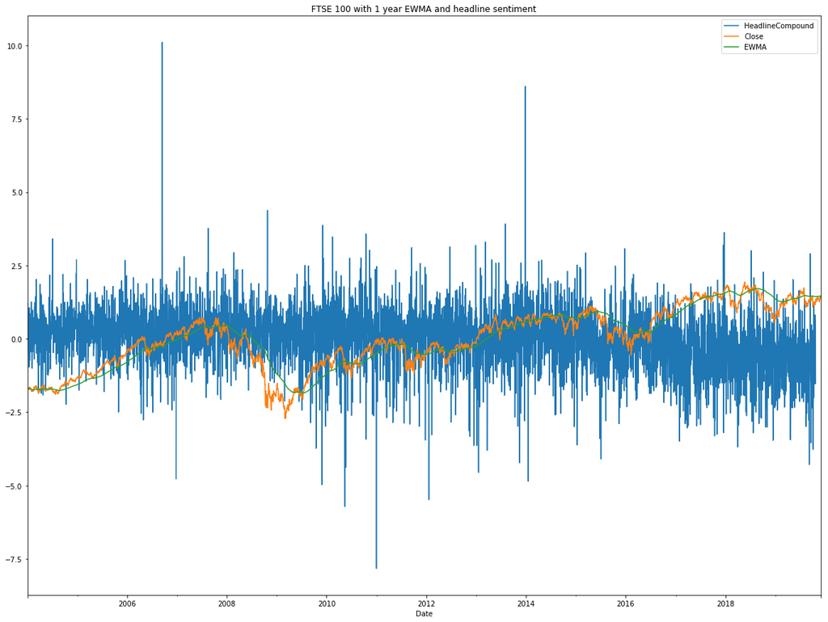

```python
#Plot headlinecompound first to overlay the index values on top
ftseSentiment1[['HeadlineCompound','Close','EWMA']].plot(figsize = (20,15))
plt.title('FTSE 100 with 1 year EWMA and headline sentiment')
```

**Comments**  
There is a lot of noise which can be seen above from the sentiment analysis on the news headlines. The lag of when news headlines are published and when this is incorporated in the price of the index can be seen. In early 2018, a news headline had a high positive sentiment score and a few days later the stock price had increased. To improve on this, key words should be looked at to look at the impact on the stock market.

#### Q. The news articles have been publlished by The Guardian, but do these news articles have an effect on other Global indicies?

```python
#Apply the EWMA with a period of 1 year similar to the FTSE 100 dataframe
SP500Conversion['EWMA'] = SP500Conversion['SP500_Close_USD'].ewm(span=253).mean()
SP500Conversion.head()
```

| Date | SP500_Close_USD | USD_Price | SP500_Close_GBP | EWMA |
| --- | --- | --- | --- | --- |
| 2004-01-02 | 1108.479980 | 0.5576 | 618.088437 | 1108.479980 |
| 2004-01-03 | 1108.479980 | 0.5576 | 618.088437 | 1108.479980 |
| 2004-01-04 | 1108.479980 | 0.5576 | 618.088437 | 1108.479980 |
| 2004-01-05 | 1122.219971 | 0.5535 | 621.148754 | 1111.955816 |
| 2004-01-06 | 1123.670044 | 0.5490 | 616.894854 | 1114.335849 |

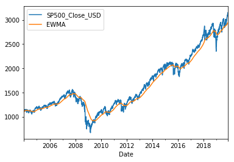

```python
SP500Conversion[['SP500_Close_USD','EWMA']].plot()
```

```python
SP500Conversion['Difference'] = SP500Conversion['SP500_Close_USD'] - SP500Conversion['EWMA']
SP500Conversion.head()
```

| Date | SP500_Close_USD | USD_Price | SP500_Close_GBP | EWMA | Difference |
| --- | --- | --- | --- | --- | --- |
| 2004-01-02 | 1108.479980 | 0.5576 | 618.088437 | 1108.479980 | 0.000000 |
| 2004-01-03 | 1108.479980 | 0.5576 | 618.088437 | 1108.479980 | 0.000000 |
| 2004-01-04 | 1108.479980 | 0.5576 | 618.088437 | 1108.479980 | 0.000000 |
| 2004-01-05 | 1122.219971 | 0.5535 | 621.148754 | 1111.955816 | 10.264155 |
| 2004-01-06 | 1123.670044 | 0.5490 | 616.894854 | 1114.335849 | 9.334195 |

```python
def trading_strat(num):
    if num > 0:
        return "Long"
    elif num <0:
        return "Short"
    else:
        return "Hold"

SP500Conversion['Trading_Strategy'] = SP500Conversion['Difference'].apply(trading_strat)
SP500Conversion.head()
```

| Date | SP500_Close_USD | USD_Price | SP500_Close_GBP | EWMA | Difference | Trading_Strategy |
| --- | --- | --- | --- | --- | --- | --- |
| 2004-01-02 | 1108.479980 | 0.5576 | 618.088437 | 1108.479980 | 0.000000 | Hold |
| 2004-01-03 | 1108.479980 | 0.5576 | 618.088437 | 1108.479980 | 0.000000 | Hold |
| 2004-01-04 | 1108.479980 | 0.5576 | 618.088437 | 1108.479980 | 0.000000 | Hold |
| 2004-01-05 | 1122.219971 | 0.5535 | 621.148754 | 1111.955816 | 10.264155 | Long |
| 2004-01-06 | 1123.670044 | 0.5490 | 616.894854 | 1114.335849 | 9.334195 | Long |

```python
#Add sentiment scores to the stock data
# steps - reset index for both ftse and news articles df
#Join on date
#plot sentiment against the time series plot

#Create new index for ftseTime df
SP500Conversion1 = SP500Conversion.reset_index()
SP500Conversion1.head()
```

|  | Date | SP500_Close_USD | USD_Price | SP500_Close_GBP | EWMA | Difference | Trading_Strategy |
| --- | --- | --- | --- | --- | --- | --- | --- |
| 0 | 2004-01-02 | 1108.479980 | 0.5576 | 618.088437 | 1108.479980 | 0.000000 | Hold |
| 1 | 2004-01-03 | 1108.479980 | 0.5576 | 618.088437 | 1108.479980 | 0.000000 | Hold |
| 2 | 2004-01-04 | 1108.479980 | 0.5576 | 618.088437 | 1108.479980 | 0.000000 | Hold |
| 3 | 2004-01-05 | 1122.219971 | 0.5535 | 621.148754 | 1111.955816 | 10.264155 | Long |
| 4 | 2004-01-06 | 1123.670044 | 0.5490 | 616.894854 | 1114.335849 | 9.334195 | Long |

```python
SP500Sentiment = pd.merge(SP500Conversion1,newsarticlesdf10,left_on = "Date", right_on = "PublishDate", how = "left")
SP500Sentiment.head()
```

|  | Date | SP500_Close_USD | USD_Price | SP500_Close_GBP | EWMA | Difference | Trading_Strategy | PublishDate | HeadlineCompound | TopicCompound |
| --- | --- | --- | --- | --- | --- | --- | --- | --- | --- | --- |
| 0 | 2004-01-02 | 1108.479980 | 0.5576 | 618.088437 | 1108.479980 | 0.000000 | Hold | 2004-01-02 | -0.115915 | -0.355777 |
| 1 | 2004-01-03 | 1108.479980 | 0.5576 | 618.088437 | 1108.479980 | 0.000000 | Hold | 2004-01-03 | -0.045793 | -0.290373 |
| 2 | 2004-01-04 | 1108.479980 | 0.5576 | 618.088437 | 1108.479980 | 0.000000 | Hold | 2004-01-04 | 0.037876 | -0.458543 |
| 3 | 2004-01-05 | 1122.219971 | 0.5535 | 621.148754 | 1111.955816 | 10.264155 | Long | 2004-01-05 | 0.027370 | -0.348022 |
| 4 | 2004-01-06 | 1123.670044 | 0.5490 | 616.894854 | 1114.335849 | 9.334195 | Long | 2004-01-06 | -0.032039 | -0.378247 |

```python
#Make Date the index for the dataframe
SP500Sentiment1 = SP500Sentiment.set_index('Date')
SP500Sentiment1.head()
```

| Date | SP500_Close_USD | USD_Price | SP500_Close_GBP | EWMA | Difference | Trading_Strategy | PublishDate | HeadlineCompound | TopicCompound |
| --- | --- | --- | --- | --- | --- | --- | --- | --- | --- |
| 2004-01-02 | 1108.479980 | 0.5576 | 618.088437 | 1108.479980 | 0.000000 | Hold | 2004-01-02 | -0.115915 | -0.355777 |
| 2004-01-03 | 1108.479980 | 0.5576 | 618.088437 | 1108.479980 | 0.000000 | Hold | 2004-01-03 | -0.045793 | -0.290373 |
| 2004-01-04 | 1108.479980 | 0.5576 | 618.088437 | 1108.479980 | 0.000000 | Hold | 2004-01-04 | 0.037876 | -0.458543 |
| 2004-01-05 | 1122.219971 | 0.5535 | 621.148754 | 1111.955816 | 10.264155 | Long | 2004-01-05 | 0.027370 | -0.348022 |
| 2004-01-06 | 1123.670044 | 0.5490 | 616.894854 | 1114.335849 | 9.334195 | Long | 2004-01-06 | -0.032039 | -0.378247 |

```python
#Normalize the close price and EWMA to plot headline sentiment values on same graph using standardscaler.
SP500Sentiment1[['SP500_Close_USD','EWMA','HeadlineCompound']] = StandardScaler().fit_transform(SP500Sentiment1[['SP500_Close_USD','EWMA','HeadlineCompound']])
SP500Sentiment1.head()
```

| Date | SP500_Close_USD | USD_Price | SP500_Close_GBP | EWMA | Difference | Trading_Strategy | PublishDate | HeadlineCompound | TopicCompound |
| --- | --- | --- | --- | --- | --- | --- | --- | --- | --- |
| 2004-01-02 | -0.955544 | 0.5576 | 618.088437 | -0.944074 | 0.000000 | Hold | 2004-01-02 | -0.512171 | -0.355777 |
| 2004-01-03 | -0.955544 | 0.5576 | 618.088437 | -0.944074 | 0.000000 | Hold | 2004-01-03 | 0.277442 | -0.290373 |
| 2004-01-04 | -0.955544 | 0.5576 | 618.088437 | -0.944074 | 0.000000 | Hold | 2004-01-04 | 1.219607 | -0.458543 |
| 2004-01-05 | -0.932324 | 0.5535 | 621.148754 | -0.937836 | 10.264155 | Long | 2004-01-05 | 1.101302 | -0.348022 |
| 2004-01-06 | -0.929873 | 0.5490 | 616.894854 | -0.933565 | 9.334195 | Long | 2004-01-06 | 0.432325 | -0.378247 |

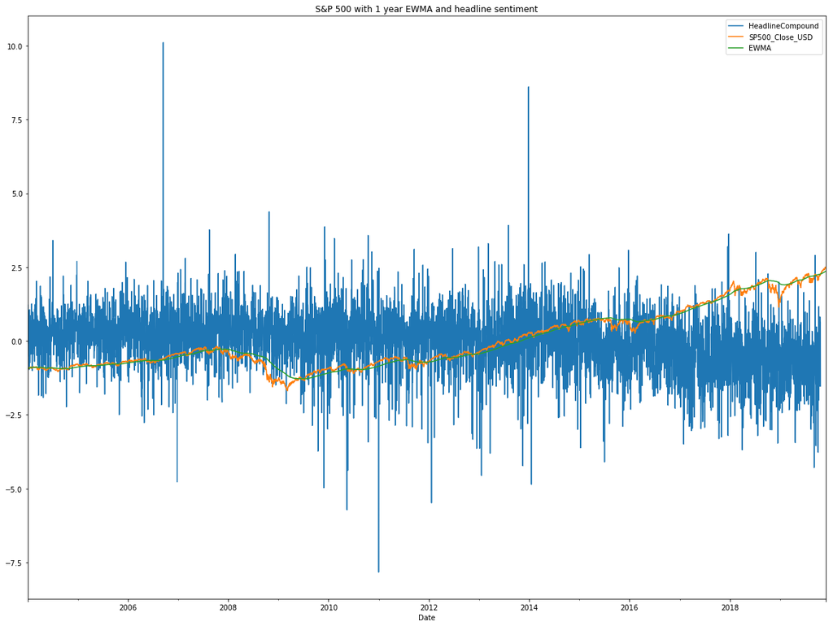

```python
#Plot headlinecompound first to overlay the index values on top
SP500Sentiment1[['HeadlineCompound','SP500_Close_USD','EWMA']].plot(figsize = (20,15))
plt.title('S&P 500 with 1 year EWMA and headline sentiment')
```

#### Q. Is there any correlation between news headline sentiment and stock price?

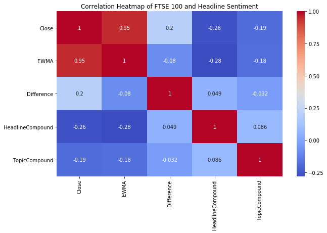

```python
plt.subplots(figsize = (10,6))
graph1 = sns.heatmap(ftseSentiment.corr(method = 'spearman'),cmap = 'coolwarm',annot = True)
plt.title('Correlation Heatmap of FTSE 100 and Headline Sentiment')
```

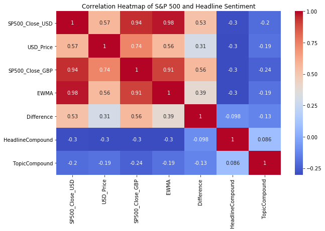

```python
plt.subplots(figsize = (10,6))
graph1 = sns.heatmap(SP500Sentiment.corr(method = 'spearman'),cmap = 'coolwarm',annot = True)
plt.title('Correlation Heatmap of S&P 500 and Headline Sentiment')
```

**Comments**  
Spearman correlation is used to measure the degree of association between two variables [34]. There is a weak negative correlation between the headline sentiment and closing price of the stock index for both FTSE 100 and S&P500. This may produce poor results when looking at how the stock price changes with news headlines.

#### Q. Can news headline sentiment be used to predict the stock index values?

##### Multiple Linear Regression

```python
from sklearn.model_selection import train_test_split
from sklearn.metrics import mean_squared_error, r2_score
```

```python
ftseSentiment.head()
```

|  | Date | Close | EWMA | Difference | Trading_Strategy | PublishDate | HeadlineCompound | TopicCompound | Sentiment_Strategy |
| --- | --- | --- | --- | --- | --- | --- | --- | --- | --- |
| 0 | 2004-01-02 | 4510.2 | 4510.200000 | 0.000000 | Hold | 2004-01-02 | -0.115915 | -0.355777 | Hold |
| 1 | 2004-01-03 | 4510.2 | 4510.200000 | 0.000000 | Hold | 2004-01-03 | -0.045793 | -0.290373 | Hold |
| 2 | 2004-01-04 | 4510.2 | 4510.200000 | 0.000000 | Hold | 2004-01-04 | 0.037876 | -0.458543 | Hold |
| 3 | 2004-01-05 | 4513.3 | 4510.984214 | 2.315786 | Long | 2004-01-05 | 0.027370 | -0.348022 | Buy |
| 4 | 2004-01-06 | 4505.2 | 4509.809009 | -4.609009 | Short | 2004-01-06 | -0.032039 | -0.378247 | Sell |

```python
#Format date to ordinal to run through linear regression model as linear regression model does not accept date as datetime format
import datetime as dt
ftseSentiment['DateOrdinal'] = ftseSentiment['Date'].map(dt.datetime.toordinal)
ftseSentiment['PublishDateOrdinal'] = ftseSentiment['PublishDate'].map(dt.datetime.toordinal)
ftseSentiment.head()
```

|  | Date | Close | EWMA | Difference | Trading_Strategy | PublishDate | HeadlineCompound | TopicCompound | Sentiment_Strategy | DateOrdinal | PublishDateOrdinal |
| --- | --- | --- | --- | --- | --- | --- | --- | --- | --- | --- | --- |
| 0 | 2004-01-02 | 4510.2 | 4510.200000 | 0.000000 | Hold | 2004-01-02 | -0.115915 | -0.355777 | Hold | 731582 | 731582 |
| 1 | 2004-01-03 | 4510.2 | 4510.200000 | 0.000000 | Hold | 2004-01-03 | -0.045793 | -0.290373 | Hold | 731583 | 731583 |
| 2 | 2004-01-04 | 4510.2 | 4510.200000 | 0.000000 | Hold | 2004-01-04 | 0.037876 | -0.458543 | Hold | 731584 | 731584 |
| 3 | 2004-01-05 | 4513.3 | 4510.984214 | 2.315786 | Long | 2004-01-05 | 0.027370 | -0.348022 | Buy | 731585 | 731585 |
| 4 | 2004-01-06 | 4505.2 | 4509.809009 | -4.609009 | Short | 2004-01-06 | -0.032039 | -0.378247 | Sell | 731586 | 731586 |

```python
X = ftseSentiment[['DateOrdinal','PublishDateOrdinal','HeadlineCompound']]
y = ftseSentiment['Close']
```

```python
X.head()
```

|  | DateOrdinal | PublishDateOrdinal | HeadlineCompound |
| --- | --- | --- | --- |
| 0 | 731582 | 731582 | -0.115915 |
| 1 | 731583 | 731583 | -0.045793 |
| 2 | 731584 | 731584 | 0.037876 |
| 3 | 731585 | 731585 | 0.027370 |
| 4 | 731586 | 731586 | -0.032039 |

```python
y.head()
```

```
0    4510.2
1    4510.2
2    4510.2
3    4513.3
4    4505.2
Name: Close, dtype: float64
```

```python
#Split the dataframe into training and test sets. Code for MLR adapted from StackAbuse.com[35]
#Enter a value for random state for reproducibility
X_train,X_test,y_train,y_test = train_test_split(X,y,test_size = 0.3,random_state = 42)
```

```python
#Create MLR
from sklearn.linear_model import LinearRegression
mlr_mod = LinearRegression()
```

```python
X_train.fillna(X_train.mean(),inplace = True)
X_test.fillna(X_test.mean(),inplace = True)
```

```python
#Fit the model
mlr_mod.fit(X_train,y_train)
```

```
LinearRegression(copy_X=True, fit_intercept=True, n_jobs=None,
         normalize=False)
```

```python
#make predictions on the test set
pred_price = mlr_mod.predict(X_test)
```

```python
pred_price[1]
```

```
4855.56595153315
```

```python
#compute RMSE and R2 statistics
test_set_rmse = (np.sqrt(mean_squared_error(y_test,pred_price)))
test_set_r2 = r2_score(y_test,pred_price)
```

```python
print(test_set_rmse)
```

```
583.261243226277
```

```python
print(test_set_r2)
```

```
0.6186507550899086
```

```python
prediction_values = pd.DataFrame({'Actual':y_test,'Predicted':pred_price})
prediction_values.head()
```

|  | Actual | Predicted |
| --- | --- | --- |
| 4808 | 7382.35 | 6890.133084 |
| 157 | 4491.60 | 4855.565952 |
| 1370 | 6535.20 | 5393.467381 |
| 5320 | 7701.31 | 7115.865261 |
| 101 | 4489.70 | 4830.814881 |

```python
X_test
```

|  | DateOrdinal | PublishDateOrdinal | HeadlineCompound |
| --- | --- | --- | --- |
| 4808 | 736390 | 736390 | -0.117348 |
| 157 | 731739 | 731739 | 0.054919 |
| 1370 | 732952 | 732952 | -0.104990 |
| 5320 | 736902 | 736902 | -0.164105 |
| 101 | 731683 | 731683 | 0.061007 |
| ... | ... | ... | ... |
| 4691 | 736273 | 736273 | -0.230370 |
| 1578 | 733160 | 733160 | -0.113007 |
| 4562 | 736144 | 736144 | 0.021122 |
| 1615 | 733197 | 733197 | -0.010433 |
| 4205 | 735787 | 735787 | -0.105428 |

1744 rows × 3 columns

```python
y_test
```

```
4808    7382.35
157     4491.60
1370    6535.20
5320    7701.31
101     4489.70
         ...
4691    6693.26
1578    6090.40
4562    6360.06
1615    5970.10
4205    6490.70
Name: Close, Length: 1744, dtype: float64
```

```python
#Merge predicted values to the X_test by index
predicted_test_set = X_test.merge(prediction_values,left_index = True, right_index = True)
predicted_test_set.reset_index(drop = True, inplace = True)
predicted_test_set.head()
```

|  | DateOrdinal | PublishDateOrdinal | HeadlineCompound | Actual | Predicted |
| --- | --- | --- | --- | --- | --- |
| 0 | 736390 | 736390 | -0.117348 | 7382.35 | 6890.133084 |
| 1 | 731739 | 731739 | 0.054919 | 4491.60 | 4855.565952 |
| 2 | 732952 | 732952 | -0.104990 | 6535.20 | 5393.467381 |
| 3 | 736902 | 736902 | -0.164105 | 7701.31 | 7115.865261 |
| 4 | 731683 | 731683 | 0.061007 | 4489.70 | 4830.814881 |

```python
dt = datetime.fromordinal(736390)
dt
```

```
datetime.datetime(2017, 3, 2, 0, 0)
```

```python
#Change Date column from ordinal to datetime to plot
predicted_test_set['NewDate'] = predicted_test_set['DateOrdinal'].map(date.fromordinal)
predicted_test_set.head()
```

|  | DateOrdinal | PublishDateOrdinal | HeadlineCompound | Actual | Predicted | NewDate |
| --- | --- | --- | --- | --- | --- | --- |
| 0 | 736390 | 736390 | -0.117348 | 7382.35 | 6890.133084 | 2017-03-02 |
| 1 | 731739 | 731739 | 0.054919 | 4491.60 | 4855.565952 | 2004-06-07 |
| 2 | 732952 | 732952 | -0.104990 | 6535.20 | 5393.467381 | 2007-10-03 |
| 3 | 736902 | 736902 | -0.164105 | 7701.31 | 7115.865261 | 2018-07-27 |
| 4 | 731683 | 731683 | 0.061007 | 4489.70 | 4830.814881 | 2004-04-12 |

```python
#Sort the df by publish date and reset the index
predicted_test_set.sort_values(by = 'NewDate',inplace = True)
predicted_test_set.reset_index(drop = True, inplace = True)
predicted_test_set.head()
```

|  | DateOrdinal | PublishDateOrdinal | HeadlineCompound | Actual | Predicted | NewDate |
| --- | --- | --- | --- | --- | --- | --- |
| 0 | 731590 | 731590 | 0.019900 | 4466.3 | 4792.952221 | 2004-01-10 |
| 1 | 731594 | 731594 | -0.156183 | 4461.4 | 4805.838068 | 2004-01-14 |
| 2 | 731596 | 731596 | 0.022162 | 4487.9 | 4795.419691 | 2004-01-16 |
| 3 | 731597 | 731597 | 0.023881 | 4487.9 | 4795.745942 | 2004-01-17 |
| 4 | 731599 | 731599 | -0.067649 | 4518.1 | 4802.409673 | 2004-01-19 |

```python
#Set NewDate as the index
predicted_test_set1 = predicted_test_set.set_index('NewDate')
predicted_test_set1.head()
```

| NewDate | DateOrdinal | PublishDateOrdinal | HeadlineCompound | Actual | Predicted |
| --- | --- | --- | --- | --- | --- |
| 2004-01-10 | 731590 | 731590 | 0.019900 | 4466.3 | 4792.952221 |
| 2004-01-14 | 731594 | 731594 | -0.156183 | 4461.4 | 4805.838068 |
| 2004-01-16 | 731596 | 731596 | 0.022162 | 4487.9 | 4795.419691 |
| 2004-01-17 | 731597 | 731597 | 0.023881 | 4487.9 | 4795.745942 |
| 2004-01-19 | 731599 | 731599 | -0.067649 | 4518.1 | 4802.409673 |

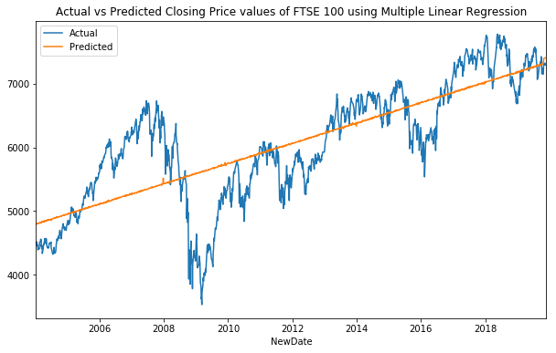

```python
predicted_test_set1[['Actual','Predicted']].plot(figsize = (10,6))
plt.title('Actual vs Predicted Closing Price values of FTSE 100 using Multiple Linear Regression')
```

**Comments**  
Although the predicted values follow the same trend as the actual closing price values, the linear regression model does not capture the sudden drops of the price such as during the financial crisis. If the linear regression model was implemented to predict stock prices, heavy losses would have been suffered during the financial crisis.